# FINAL_mirror-exp_wild-pop

Allison Davis

November 19, 2019

## Data collection

- raw data: occurance number and preference score for each individual fish (left, right, NA)
- pref data: preference scores for tank A, B, combo of A and B, and average of A and B
  - combo score determined as left/(left+right) for total left and right occurances
  - average score determined by averaging tank A pref score and tank B pref score
- separated all data by species
- original analyses w/20 individuals showed a significant difference between using the TOT.PROP vs AVG.PROP for latipinna only; for all tests, will repeat with AVG.PROP to see if this changes the results
  - Tests includind AVG.PROP in place of TOT.PROP don’t really change the values of the statistical tests. Will coninue with TOT.PROP.

### Analyses

#### Final analysis

**Data**

```r
library(curl)

rawEX <- curl("https://raw.githubusercontent.com/allisondavis/mirror-exp_wild-pop/master/adavis_mirexp_wild_raw.csv")

rawEX <- read.csv(rawEX, header = TRUE, sep = ",", stringsAsFactors = TRUE)

LAT_rawEX <- rawEX[rawEX$X.U.FEFF.SPP == "P.lat",]
FORM_rawEX <- rawEX[rawEX$X.U.FEFF.SPP == "P.form",]

tanksEX <- curl("https://raw.githubusercontent.com/allisondavis/mirror-exp_wild-pop/master/adavis_mirexp_wild_tanks.csv")

tanksEX <- read.csv(tanksEX, header = TRUE, sep = ",", stringsAsFactors = TRUE)

LAT_tankEX <- tanksEX[tanksEX$X.U.FEFF.SPP == "P.lat",]
FORM_tankEX <- tanksEX[tanksEX$X.U.FEFF.SPP == "P.form",]
```

##### With participation outliers

“Outliers” determined as those who did not move for >3 consecutive minutes. * Sailfin: Rumi (in raw species dataset) * Amazons: Cayenne and Gretchen (and in raw species dataset)

**New Datasets**

```r
LAT_rawextraP <- LAT_rawEX[-c(16),]
LAT_tankextraP <- LAT_tankEX[-c(31,32),]
LAT_rawextraP <- LAT_rawextraP[,-c(19)]

FORM_rawextraP <- FORM_rawEX[-c(3,11),]
FORM_tankextraP <- FORM_tankEX[-c(5,6,21,22),]

rawextra2 <- rbind(LAT_rawextraP, FORM_rawextraP)
tankextra2 <- rbind(LAT_tankextraP, FORM_tankextraP)
```

**Checks for normality**: both K-S tests and Shapiro-Wilk’s tests are not signifiant, indicating normal data distribution

See qqplots in visualizations. Below I perform the Kolmogorov-Smirnov (K-S) test and the Shapiro-Wilk’s test. If signficant, than it’s NOT normal.

```r
ks.test(LAT_rawextraP$LI.TOT, "pnorm", mean=mean(LAT_rawextraP$LI.TOT), sd=sd(LAT_rawextraP$LI.TOT))
```

```
##
##  One-sample Kolmogorov-Smirnov test
##
## data:  LAT_rawextraP$LI.TOT
## D = 0.16364, p-value = 0.4909
## alternative hypothesis: two-sided
```

```r
shapiro.test(LAT_rawextraP$LI.TOT)
```

```
##
##  Shapiro-Wilk normality test
##
## data:  LAT_rawextraP$LI.TOT
## W = 0.94654, p-value = 0.2277
```

```r
ks.test(FORM_rawextraP$LI.TOT, "pnorm", mean=mean(FORM_rawextraP$LI.TOT), sd=sd(FORM_rawextraP$LI.TOT))
```

```
##
##  One-sample Kolmogorov-Smirnov test
##
## data:  FORM_rawextraP$LI.TOT
## D = 0.15466, p-value = 0.5373
## alternative hypothesis: two-sided
```

```r
shapiro.test(FORM_rawextraP$LI.TOT)
```

```
##
##  Shapiro-Wilk normality test
##
## data:  FORM_rawextraP$LI.TOT
## W = 0.94617, p-value = 0.2053
```

**Variance**: overall, not significant (0.50, 95% CI 0.58-3.05) [not any different for greater or less]

```r
var.test(LAT_rawextraP$LI.TOT, FORM_rawextraP$LI.TOT, alternative = "two.sided", conf.level = 0.95)
```

```
##
##  F test to compare two variances
##
## data:  LAT_rawextraP$LI.TOT and FORM_rawextraP$LI.TOT
## F = 1.3259, num df = 23, denom df = 24, p-value = 0.4972
## alternative hypothesis: true ratio of variances is not equal to 1
## 95 percent confidence interval:
##  0.5810036 3.0481000
## sample estimates:
## ratio of variances
##           1.325891
```

```r
var.test(LAT_rawextraP$LI.TOT, FORM_rawextraP$LI.TOT, alternative = "greater", conf.level = 0.95)
```

```
##
##  F test to compare two variances
##
## data:  LAT_rawextraP$LI.TOT and FORM_rawextraP$LI.TOT
## F = 1.3259, num df = 23, denom df = 24, p-value = 0.2486
## alternative hypothesis: true ratio of variances is greater than 1
## 95 percent confidence interval:
##  0.6651941       Inf
## sample estimates:
## ratio of variances
##           1.325891
```

```r
var.test(LAT_rawextraP$LI.TOT, FORM_rawextraP$LI.TOT, alternative = "less", conf.level = 0.95)
```

```
##
##  F test to compare two variances
##
## data:  LAT_rawextraP$LI.TOT and FORM_rawextraP$LI.TOT
## F = 1.3259, num df = 23, denom df = 24, p-value = 0.7514
## alternative hypothesis: true ratio of variances is less than 1
## 95 percent confidence interval:
##  0.000000 2.658424
## sample estimates:
## ratio of variances
##           1.325891
```

**T- tests using LI instead of total proportion**

- tank differences: still none

```r
t.test(LAT_rawextraP$LI.A, LAT_rawextraP$LI.B, paired = TRUE, alternative = "two.sided")
```

```
##
##  Paired t-test
##
## data:  LAT_rawextraP$LI.A and LAT_rawextraP$LI.B
## t = -0.093344, df = 23, p-value = 0.9264
## alternative hypothesis: true difference in means is not equal to 0
## 95 percent confidence interval:
##  -9.214437  8.418775
## sample estimates:
## mean of the differences
##              -0.3978309
```

```r
t.test(FORM_rawextraP$LI.A, FORM_rawextraP$LI.B, paired = TRUE, alternative = "two.sided")
```

```
##
##  Paired t-test
##
## data:  FORM_rawextraP$LI.A and FORM_rawextraP$LI.B
## t = -1.004, df = 24, p-value = 0.3254
## alternative hypothesis: true difference in means is not equal to 0
## 95 percent confidence interval:
##  -11.167715   3.858146
## sample estimates:
## mean of the differences
##               -3.654785
```

- eye preferences: neither species with eye preference

```r
t.test(LAT_rawextraP$LI.TOT, mu=0, alternative = "two.sided")
```

```
##
##  One Sample t-test
##
## data:  LAT_rawextraP$LI.TOT
## t = 0.41627, df = 23, p-value = 0.6811
## alternative hypothesis: true mean is not equal to 0
## 95 percent confidence interval:
##  -3.136213  4.716355
## sample estimates:
## mean of x
## 0.7900707
```

```r
t.test(FORM_rawextraP$LI.TOT, mu=0, alternative = "two.sided")
```

```
##
##  One Sample t-test
##
## data:  FORM_rawextraP$LI.TOT
## t = 0.90469, df = 24, p-value = 0.3746
## alternative hypothesis: true mean is not equal to 0
## 95 percent confidence interval:
##  -1.872136  4.794291
## sample estimates:
## mean of x
##  1.461078
```

- differences between spp: no differences in direction of laterality or overall laterality
  - overall laterality: I took the absolute value of the index scores to see if one species was more lateralized overall (regardless of direction)

```r
t.test(LAT_rawextraP$LI.TOT, FORM_rawextraP$LI.TOT)
```

```
##
##  Welch Two Sample t-test
##
## data:  LAT_rawextraP$LI.TOT and FORM_rawextraP$LI.TOT
## t = -0.26925, df = 45.503, p-value = 0.789
## alternative hypothesis: true difference in means is not equal to 0
## 95 percent confidence interval:
##  -5.688840  4.346826
## sample estimates:
## mean of x mean of y
## 0.7900707 1.4610778
```

```r
totLAT2 <- abs(LAT_rawextraP$LI.TOT)
totFORM2 <- abs(FORM_rawextraP$LI.TOT)

t.test(totLAT2, totFORM2)
```

```
##
##  Welch Two Sample t-test
##
## data:  totLAT2 and totFORM2
## t = 0.90509, df = 46.923, p-value = 0.37
## alternative hypothesis: true difference in means is not equal to 0
## 95 percent confidence interval:
##  -1.703724  4.490358
## sample estimates:
## mean of x mean of y
##  7.463229  6.069912
```

**Repeatability**

- With z-scores of LI data (not sure if this is kosher or useful); results are the same with the raw data

```r
library(tidyverse)
LAT_rawextraP <- LAT_rawextraP %>% mutate(z.LIA = c(scale(LI.A)))

LAT_rawextraP <- LAT_rawextraP %>% mutate(z.LIB = c(scale(LI.B)))

FORM_rawextraP <- FORM_rawextraP %>% mutate(z.LIA = c(scale(LI.A)))

FORM_rawextraP <- FORM_rawextraP %>% mutate(z.LIB = c(scale(LI.B)))
```

```r
library(ggpubr)
cor.test(LAT_rawextraP$z.LIA, LAT_rawextraP$z.LIB, method ="pearson")
```

```
##
##  Pearson's product-moment correlation
##
## data:  LAT_rawextraP$z.LIA and LAT_rawextraP$z.LIB
## t = -0.54497, df = 22, p-value = 0.5913
## alternative hypothesis: true correlation is not equal to 0
## 95 percent confidence interval:
##  -0.4957295  0.3020466
## sample estimates:
##        cor
## -0.1154125
```

```r
cor.test(FORM_rawextraP$z.LIA, FORM_rawextraP$z.LIB, method = "pearson")
```

```
##
##  Pearson's product-moment correlation
##
## data:  FORM_rawextraP$z.LIA and FORM_rawextraP$z.LIB
## t = -0.58651, df = 23, p-value = 0.5632
## alternative hypothesis: true correlation is not equal to 0
## 95 percent confidence interval:
##  -0.4928818  0.2875302
## sample estimates:
##        cor
## -0.1213924
```

- With raw LI data

```r
library(ggpubr)

cor.test(LAT_rawextraP$LI.A, LAT_rawextraP$LI.B, method ="pearson")
```

```
##
##  Pearson's product-moment correlation
##
## data:  LAT_rawextraP$LI.A and LAT_rawextraP$LI.B
## t = -0.54497, df = 22, p-value = 0.5913
## alternative hypothesis: true correlation is not equal to 0
## 95 percent confidence interval:
##  -0.4957295  0.3020466
## sample estimates:
##        cor
## -0.1154125
```

```r
cor.test(FORM_rawextraP$LI.A, FORM_rawextraP$LI.B, method = "pearson")
```

```
##
##  Pearson's product-moment correlation
##
## data:  FORM_rawextraP$LI.A and FORM_rawextraP$LI.B
## t = -0.58651, df = 23, p-value = 0.5632
## alternative hypothesis: true correlation is not equal to 0
## 95 percent confidence interval:
##  -0.4928818  0.2875302
## sample estimates:
##        cor
## -0.1213924
```

**Visuals**

- Overview

```r
library(ggplot2)
library(ggsignif)
library(gridExtra)
library(ggthemes)

orig3 <- ggplot(rawEX, aes(x=X.U.FEFF.SPP, y=LI.TOT)) + geom_boxplot() + geom_point(color="gray75") + xlab("Species") + ylab("Laterality index") + ggtitle("Original Data") + theme_classic()

orig3
```

- Overview with outlier removed

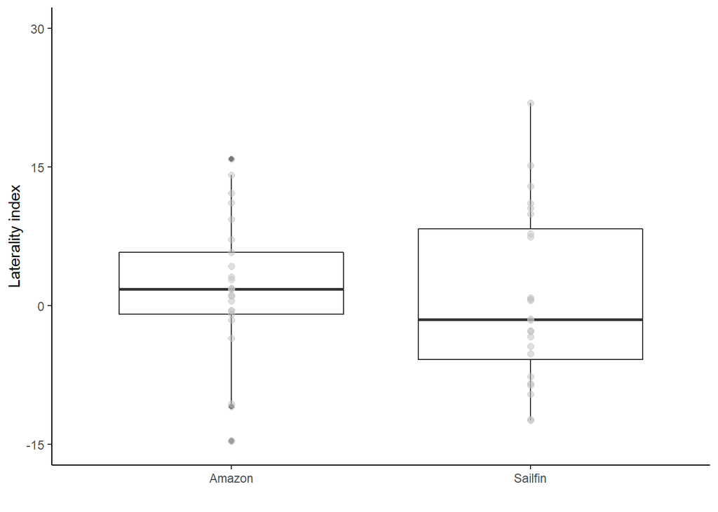

```r
library(ggplot2)
library(ggsignif)
library(gridExtra)
library(ggthemes)

library(plyr)
RAWEXTRA <- rawextra2
RAWEXTRA$X.U.FEFF.SPP <- revalue(RAWEXTRA$X.U.FEFF.SPP, c("P.lat"="Sailfin"))

RAWEXTRA$X.U.FEFF.SPP <- revalue(RAWEXTRA$X.U.FEFF.SPP, c("P.form"="Amazon"))

rem_out3 <- ggplot(RAWEXTRA, aes(x=X.U.FEFF.SPP, y=LI.TOT)) + geom_boxplot(coef=1.5) + geom_point(color="gray75", size=2, alpha=0.5) + scale_y_continuous(breaks = seq(-15, 30, 15)) +  coord_cartesian(ylim = c(-15, 30))  + ylab("Laterality index") + xlab("") +theme_classic()

rem_out3
```

```r
ggsave(rem_out3, filename = "boxplot.png", bg="transparent", width = 6, height = 4, units = "in")
```

- Overview of eye use per species
  - not sure what scale to use: min is -63, max is 27

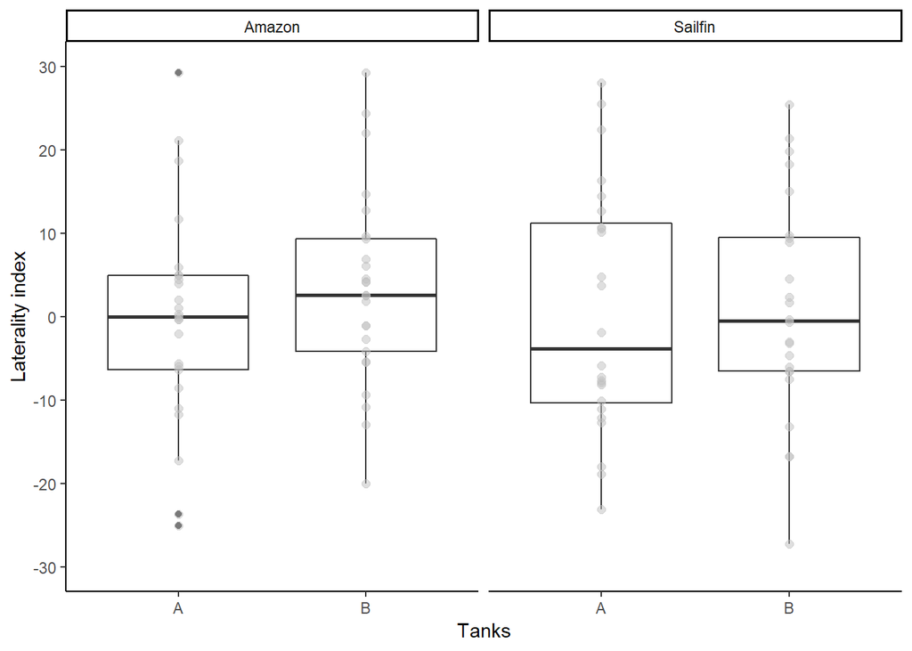

```r
library(plyr)

TANKEXTRA <- tankextra2
TANKEXTRA$X.U.FEFF.SPP <- revalue(TANKEXTRA$X.U.FEFF.SPP, c("P.lat"="Sailfin"))

TANKEXTRA$X.U.FEFF.SPP <- revalue(TANKEXTRA$X.U.FEFF.SPP, c("P.form"="Amazon"))

library(ggplot2)
library(ggsignif)
library(gridExtra)
library(ggthemes)

EYE <- ggplot(TANKEXTRA, aes(x=TANK, y=LI.TOT))+ geom_boxplot(coef=1.5) + facet_wrap(~X.U.FEFF.SPP) + geom_point(color="gray75", size=2, alpha=0.5) + scale_y_continuous(breaks = seq(-30, 30, 10)) +  coord_cartesian(ylim = c(-30, 30)) + xlab("Tanks") + ylab("Laterality index") + theme_classic()

EYE
```

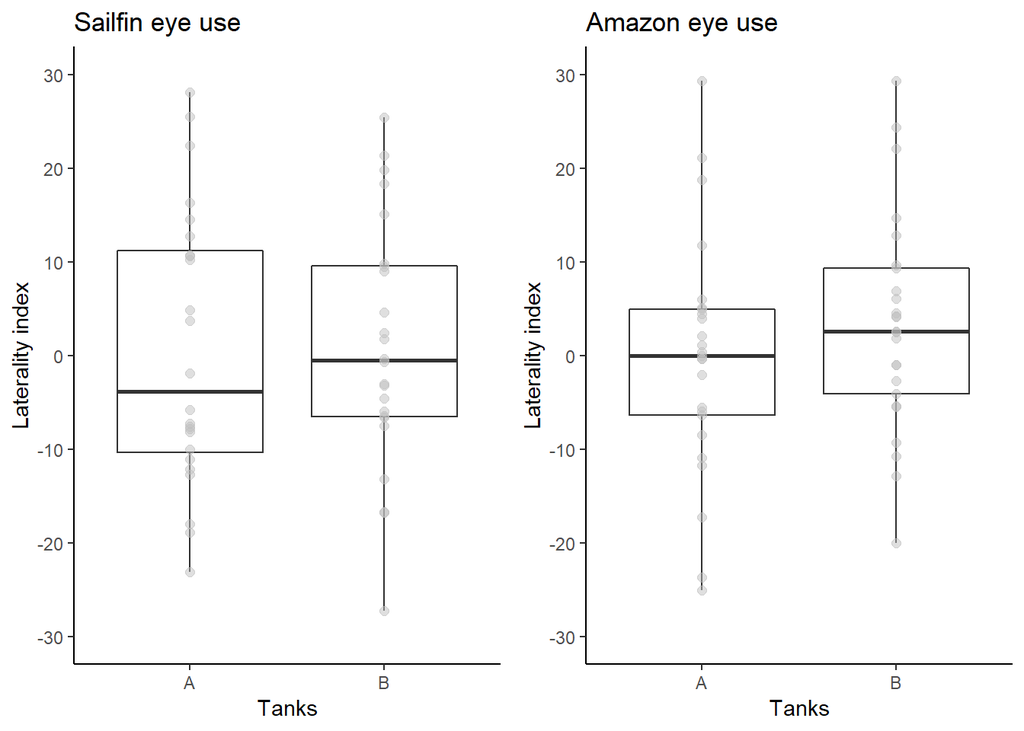

```r
ggsave(EYE, filename = "eyeuse.png", bg="transparent", width = 6, height = 4, units = "in")

LATeye2 <- ggplot(LAT_tankextraP, aes(x=TANK, y=LI.TOT))+ geom_boxplot(coef=1.5) + geom_point(color="gray75", size=2, alpha=0.5) + scale_y_continuous(breaks = seq(-30, 30, 10)) +  coord_cartesian(ylim = c(-30, 30)) + xlab("Tanks") + ylab("Laterality index") + ggtitle("Sailfin eye use") + theme_classic()

FORMeye2 <- ggplot(FORM_tankextraP, aes(x=TANK, y=LI.TOT))+ geom_boxplot(coef=3) + geom_point(color="gray75", size=2, alpha=0.5) + scale_y_continuous(breaks = seq(-30, 30, 10)) +  coord_cartesian(ylim = c(-30, 30)) + xlab("Tanks") + ylab("Laterality index") + ggtitle("Amazon eye use") + theme_classic()

grid.arrange(LATeye2, FORMeye2, ncol=2)
```

```r
library(car)
```

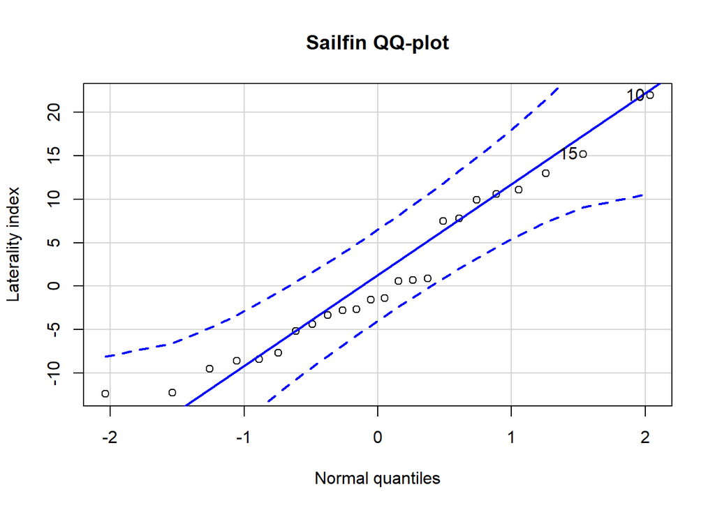

```
## [1] 10 15
```

```r
qqp(LAT_rawextraP$LI.TOT, "norm", ylab="Laterality index", xlab= "Normal quantiles", main="Sailfin QQ-plot")
```

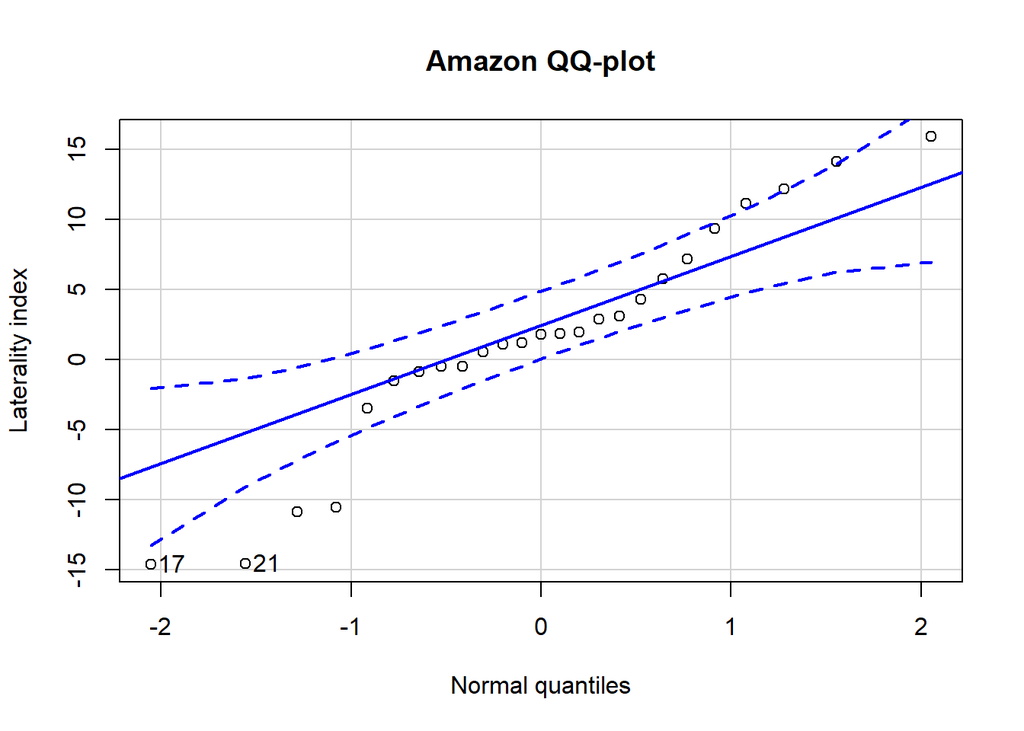

```
## [1] 17 21
```

```r
qqp(FORM_rawextraP$LI.TOT, "norm", ylab="Laterality index", xlab= "Normal quantiles", main="Amazon QQ-plot" )
```

- Histograms
  - means and spread don’t seem to be too different (which is confirmed in our t-tests and F-tests). Definitely doesn’t look normal though, not sure what you think.

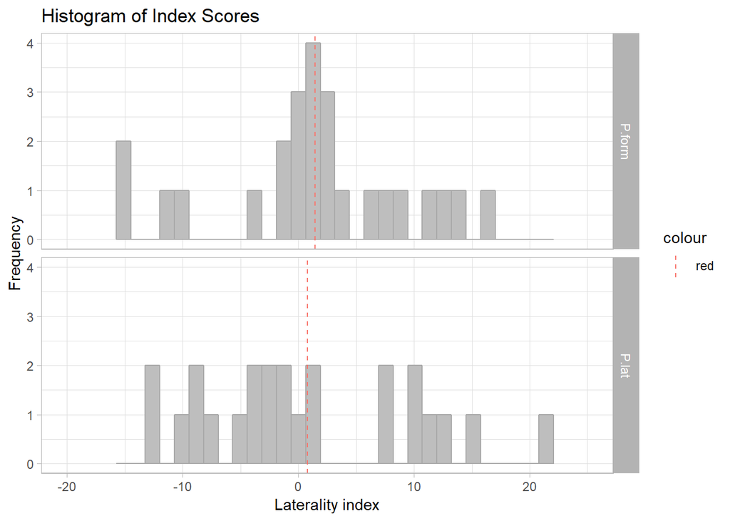

```r
library(plyr)
mu2 <- ddply(rawextra2, "X.U.FEFF.SPP", summarise, grp.mean=mean(LI.TOT))

hist2 <- ggplot(rawextra2, aes(x=LI.TOT)) + geom_histogram(color="darkgrey", fill="grey") + facet_grid(X.U.FEFF.SPP ~ .) + geom_vline(data = mu2, aes(xintercept=grp.mean, color="red"), linetype="dashed") + xlab("Laterality index") + ylab("Frequency") + ggtitle("Histogram of Index Scores") + coord_cartesian(ylim = c(0, 4), xlim = c(-20, 25)) + theme_light()

hist2 #play around with theme, don't really like classic or light
```

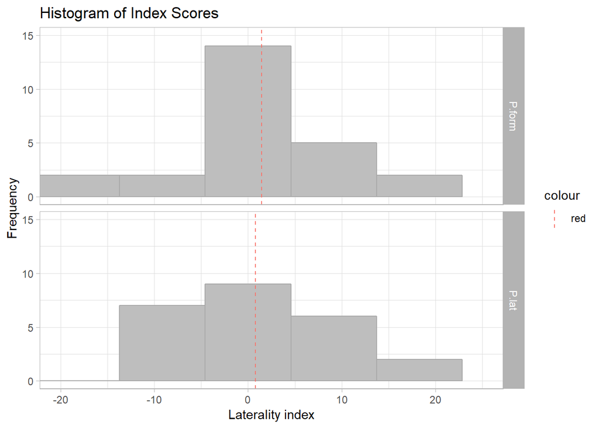

```r
hist2.1 <- ggplot(rawextra2, aes(x=LI.TOT)) + geom_histogram(color="darkgrey", fill="grey", bins = 5) + facet_grid(X.U.FEFF.SPP ~ .) + geom_vline(data = mu2, aes(xintercept=grp.mean, color="red"), linetype="dashed") + xlab("Laterality index") + ylab("Frequency") + ggtitle("Histogram of Index Scores") + coord_cartesian(ylim = c(0, 15), xlim = c(-20, 25)) + theme_light()

hist2.1
```

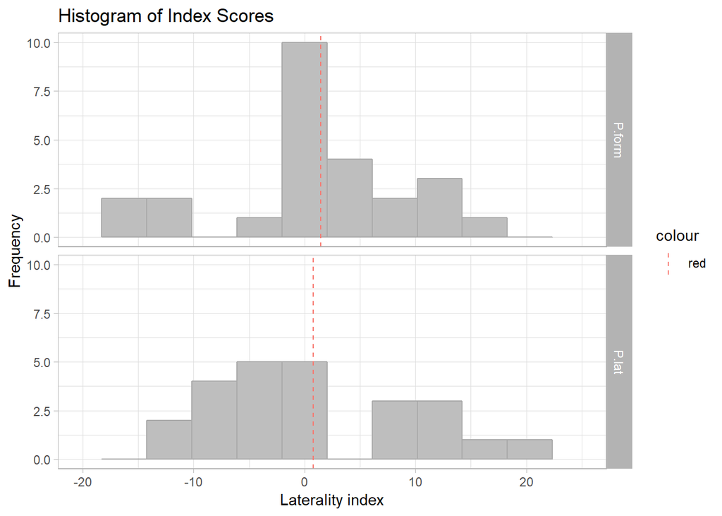

```r
hist2.2 <- ggplot(rawextra2, aes(x=LI.TOT)) + geom_histogram(color="darkgrey", fill="grey", bins = 10) + facet_grid(X.U.FEFF.SPP ~ .) + geom_vline(data = mu2, aes(xintercept=grp.mean, color="red"), linetype="dashed") + xlab("Laterality index") + ylab("Frequency") + ggtitle("Histogram of Index Scores") + coord_cartesian(ylim = c(0, 10), xlim = c(-20, 25)) + theme_light()

hist2.2
```

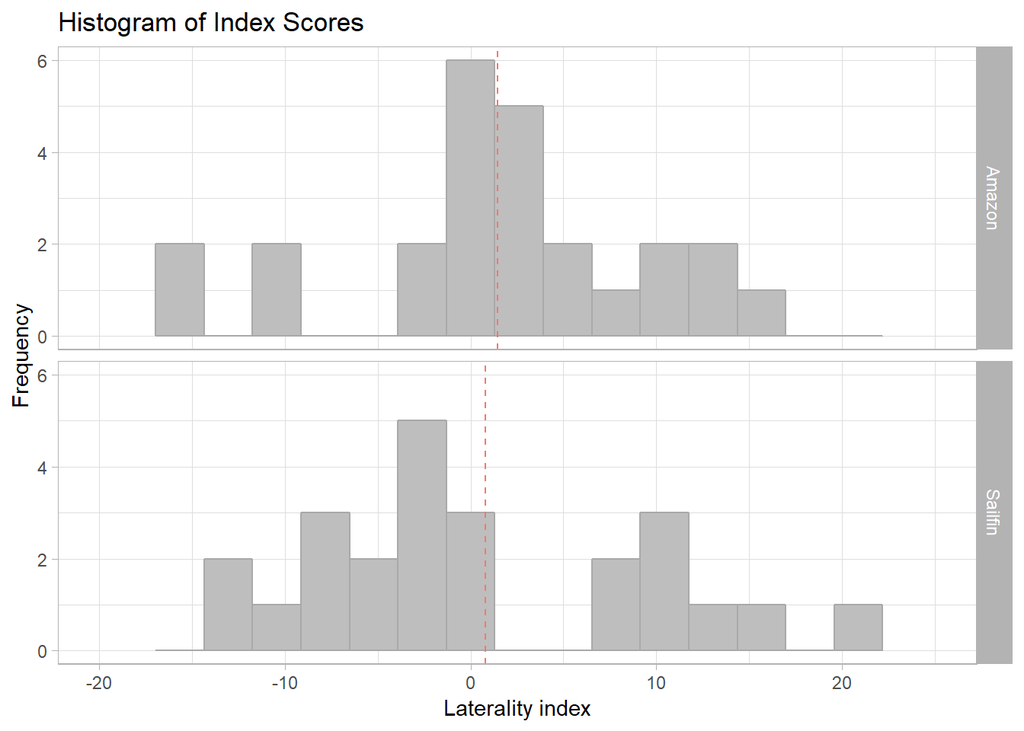

```r
mu3 <- ddply(RAWEXTRA, "X.U.FEFF.SPP", summarise, grp.mean=mean(LI.TOT))

hist2.3 <- ggplot(RAWEXTRA, aes(x=LI.TOT)) + geom_histogram(color="darkgrey", fill="grey", bins = 15) + facet_grid(X.U.FEFF.SPP ~ .) + geom_vline(data = mu3, aes(xintercept=grp.mean, color="red"), linetype="dashed") + xlab("Laterality index") + ylab("Frequency") + ggtitle("Histogram of Index Scores") + coord_cartesian(ylim = c(0, 6), xlim = c(-20, 25)) + theme_light() + theme(legend.position = "none")

hist2.3
```

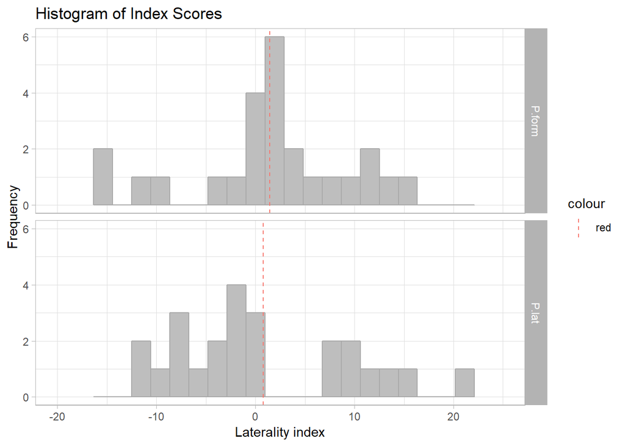

```r
ggsave(hist2.3, filename = "histogram.png", bg="transparent", width = 6, height = 4, units = "in")


hist2.4 <- ggplot(rawextra2, aes(x=LI.TOT)) + geom_histogram(color="darkgrey", fill="grey", bins = 20) + facet_grid(X.U.FEFF.SPP ~ .) + geom_vline(data = mu2, aes(xintercept=grp.mean, color="red"), linetype="dashed") + xlab("Laterality index") + ylab("Frequency") + ggtitle("Histogram of Index Scores") + coord_cartesian(ylim = c(0, 6), xlim = c(-20, 25)) + theme_light()

hist2.4
```

- Deviance from mean of absolute value scores **Not sure if I should do if the F-test wasn’t significant.**
- Z-scores **Not sure if I should do if the F-test wasn’t significant.**

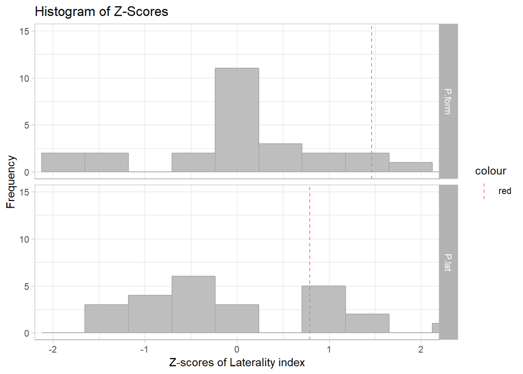

```r
library(tidyverse)

rawextra2 <- rawextra2 %>% mutate(z.LI = c(scale(LI.TOT)))

histZ <- ggplot(rawextra2, aes(x=z.LI)) + geom_histogram(color="darkgrey", fill="grey", bins = 10) + facet_grid(X.U.FEFF.SPP ~ .) + geom_vline(data = mu2, aes(xintercept=grp.mean, color="red"), linetype="dashed") + xlab("Z-scores of Laterality index") + ylab("Frequency") + ggtitle("Histogram of Z-Scores") + coord_cartesian(ylim = c(0, 15), xlim = c(-2, 2)) + theme_light()

histZ
```

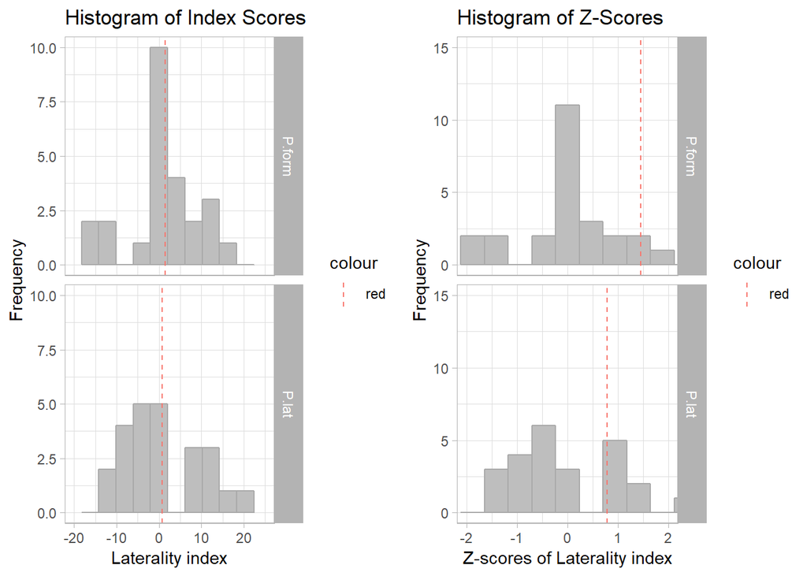

```r
grid.arrange(hist2.2, histZ, ncol=2)
```

##### With Tukey outliers

*I will be following the methods described by a number of Bisazza papers in which a laterality index is calculated, and parametric tests are used. I will present a qqplot as well to check normality (see visualizations below).*

Outlier tests

```r
library(DescTools)
```

```r
Outlier(LAT_rawEX$LI.TOT, method=c("boxplot"), value = FALSE)
```

```
## integer(0)
```

```r
Outlier(FORM_rawEX$LI.TOT, method=c("boxplot"), value = FALSE)
```

```
## [1]  3 11 19 23
```

- Still no outliers for sailfin; four outliers for amazon (Cayenne, Gretchen, Sofia, Nyx)

New Datasets

```r
FORM_rawextra <- FORM_rawEX[-c(3,11,19,23),]
FORM_tankextra <- FORM_tankEX[-c(5,6,21,22,37,38,47,48),]

rawextra <- rbind(LAT_rawEX, FORM_rawextra)
tankextra <- rbind(LAT_tankEX, FORM_tankextra)
```

Variance: still significant (p=0.007, 95% CI 1.39-7.45)

```r
var.test(LAT_rawEX$LI.TOT, FORM_rawextra$LI.TOT, alternative = "two.sided", conf.level = 0.95)
```

```
##
##  F test to compare two variances
##
## data:  LAT_rawEX$LI.TOT and FORM_rawextra$LI.TOT
## F = 3.2438, num df = 24, denom df = 22, p-value = 0.007199
## alternative hypothesis: true ratio of variances is not equal to 1
## 95 percent confidence interval:
##  1.391286 7.447418
## sample estimates:
## ratio of variances
##           3.243782
```

T- tests using LI instead of total proportion

- tank differences: still none

```r
t.test(LAT_rawEX$LI.A, LAT_rawEX$LI.B, paired = TRUE, alternative = "two.sided")
```

```
##
##  Paired t-test
##
## data:  LAT_rawEX$LI.A and LAT_rawEX$LI.B
## t = -0.51597, df = 24, p-value = 0.6106
## alternative hypothesis: true difference in means is not equal to 0
## 95 percent confidence interval:
##  -11.669385   7.001631
## sample estimates:
## mean of the differences
##               -2.333877
```

```r
t.test(FORM_rawextra$LI.A, FORM_rawextra$LI.B, paired = TRUE, alternative = "two.sided")
```

```
##
##  Paired t-test
##
## data:  FORM_rawextra$LI.A and FORM_rawextra$LI.B
## t = -0.59289, df = 22, p-value = 0.5593
## alternative hypothesis: true difference in means is not equal to 0
## 95 percent confidence interval:
##  -10.193180   5.660739
## sample estimates:
## mean of the differences
##                -2.26622
```

- eye preferences: niether species with preferences

```r
t.test(LAT_rawEX$LI.TOT, mu=0, alternative = "two.sided")
```

```
##
##  One Sample t-test
##
## data:  LAT_rawEX$LI.TOT
## t = 0.98809, df = 24, p-value = 0.333
## alternative hypothesis: true mean is not equal to 0
## 95 percent confidence interval:
##  -2.617137  7.424639
## sample estimates:
## mean of x
##  2.403751
```

```r
t.test(FORM_rawextra$LI.TOT, mu=0, alternative = "two.sided")
```

```
##
##  One Sample t-test
##
## data:  FORM_rawextra$LI.TOT
## t = 2.0299, df = 22, p-value = 0.05463
## alternative hypothesis: true mean is not equal to 0
## 95 percent confidence interval:
##  -0.0618892  5.7790752
## sample estimates:
## mean of x
##  2.858593
```

- differences between spp: no differences in direction of laterality or overall laterality
  - overall laterality: I took the absolute value of the index scores to see if one species was more lateralized overall (regardless of direction)

```r
t.test(LAT_rawEX$LI.TOT, FORM_rawextra$LI.TOT)
```

```
##
##  Welch Two Sample t-test
##
## data:  LAT_rawEX$LI.TOT and FORM_rawextra$LI.TOT
## t = -0.16181, df = 38.111, p-value = 0.8723
## alternative hypothesis: true difference in means is not equal to 0
## 95 percent confidence interval:
##  -6.144693  5.235009
## sample estimates:
## mean of x mean of y
##  2.403751  2.858593
```

```r
totLAT <- abs(LAT_rawEX$LI.TOT)
totFORM <- abs(FORM_rawextra$LI.TOT)

t.test(totLAT, totFORM)
```

```
##
##  Welch Two Sample t-test
##
## data:  totLAT and totFORM
## t = 1.7437, df = 39.012, p-value = 0.08909
## alternative hypothesis: true difference in means is not equal to 0
## 95 percent confidence interval:
##  -0.5572786  7.5227137
## sample estimates:
## mean of x mean of y
##  8.809982  5.327265
```

Visuals

- Overview

```r
library(ggplot2)
library(ggsignif)
library(gridExtra)
library(ggthemes)

orig2 <- ggplot(rawEX, aes(x=X.U.FEFF.SPP, y=LI.TOT)) + geom_boxplot() + geom_point(color="gray75") + xlab("Species") + ylab("Laterality index") + ggtitle("Original Data") + theme_classic()

orig2
```

- Overview with outlier removed

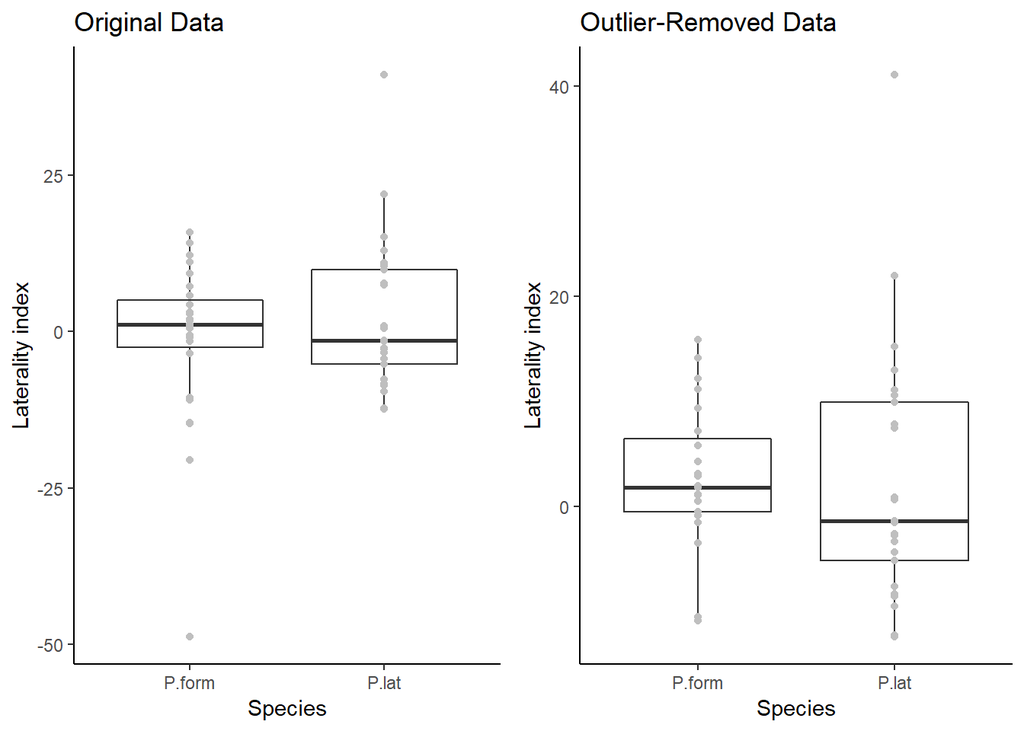

```r
library(ggplot2)
library(ggsignif)
library(gridExtra)
library(ggthemes)


rem_out2 <- ggplot(rawextra, aes(x=X.U.FEFF.SPP, y=LI.TOT)) + geom_boxplot() + geom_point(color="gray75") + xlab("Species") + ylab("Laterality index") + ggtitle("Outlier-Removed Data") + theme_classic()

grid.arrange(orig2, rem_out2, ncol=2)
```

- Overview of eye use per species
  - not sure what scale to use: min is -63, max is 27

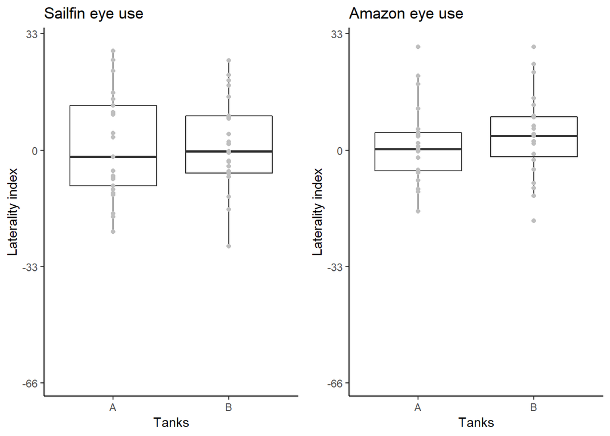

```r
LATeye <- ggplot(LAT_tankEX, aes(x=TANK, y=LI.TOT))+ geom_boxplot() + geom_point(color="gray75") + scale_y_continuous(breaks = seq(-66, 33, 33)) +  coord_cartesian(ylim = c(-65, 30)) + xlab("Tanks") + ylab("Laterality index") + ggtitle("Sailfin eye use") + theme_classic()

FORMeye <- ggplot(FORM_tankextra, aes(x=TANK, y=LI.TOT))+ geom_boxplot() + geom_point(color="gray75") + scale_y_continuous(breaks = seq(-66, 33, 33)) +  coord_cartesian(ylim = c(-65, 30)) + xlab("Tanks") + ylab("Laterality index") + ggtitle("Amazon eye use") + theme_classic()

grid.arrange(LATeye, FORMeye, ncol=2)
```

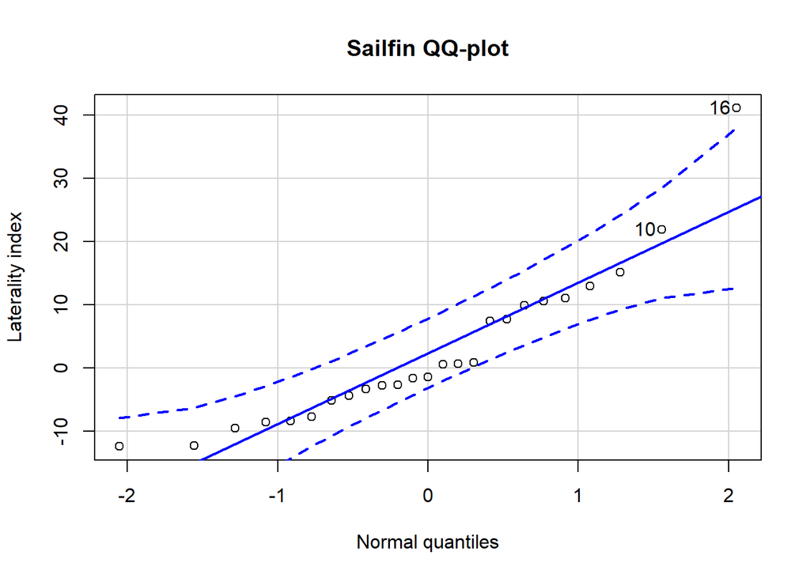

```
## [1] 16 10
```

```r
library(car)

qqp(LAT_rawEX$LI.TOT, "norm", ylab="Laterality index", xlab= "Normal quantiles", main="Sailfin QQ-plot")
```

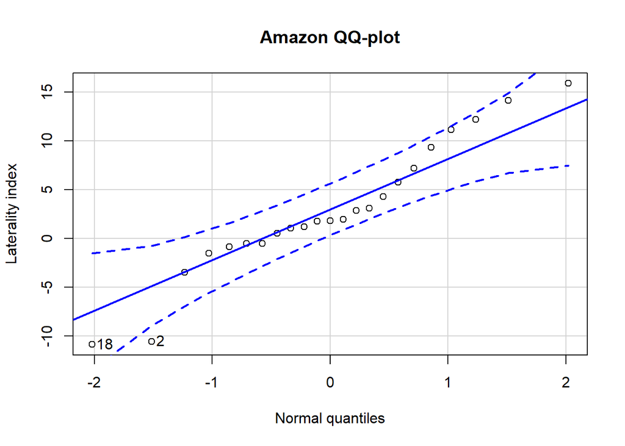

```
## [1] 18  2
```

```r
qqp(FORM_rawextra$LI.TOT, "norm", ylab="Laterality index", xlab= "Normal quantiles", main="Amazon QQ-plot" )
```

- Histograms
  - means don’t seem to be too different (which is confirmed in our t-tests), but the spread is different.

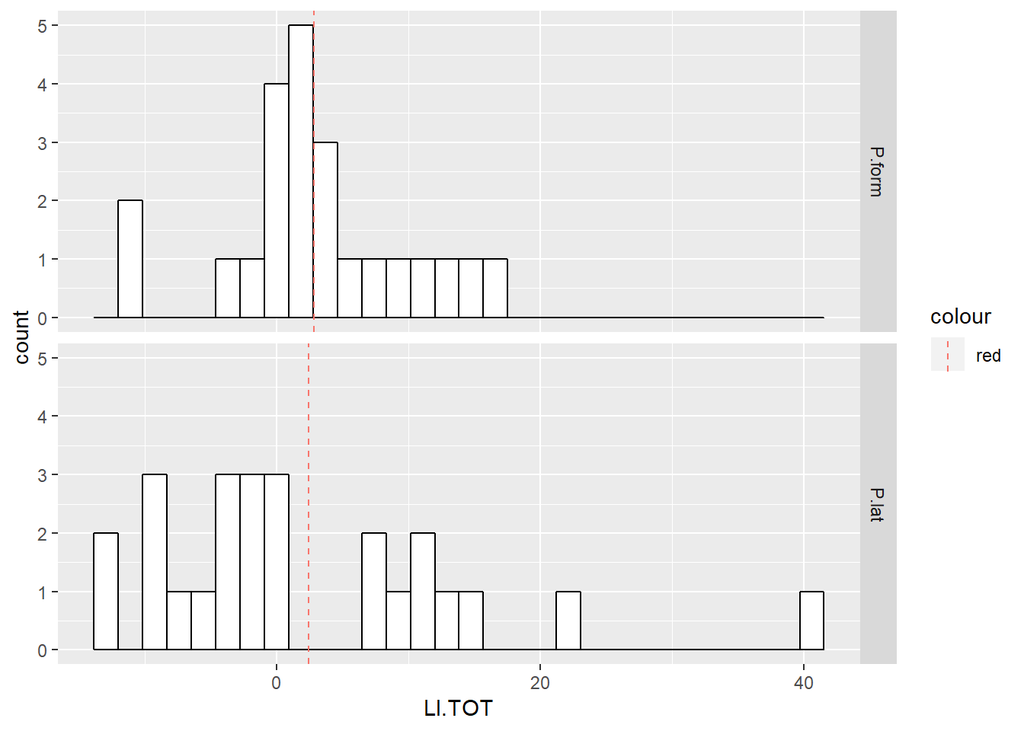

```r
library(plyr)
mu <- ddply(rawextra, "X.U.FEFF.SPP", summarise, grp.mean=mean(LI.TOT))

hist <- ggplot(rawextra, aes(x=LI.TOT)) + geom_histogram(color="black", fill="white") + facet_grid(X.U.FEFF.SPP ~ .) + geom_vline(data = mu, aes(xintercept=grp.mean, color="red"), linetype="dashed")

hist
```

- Deviance from mean of absolute value scores
- Z-scores

#### More fish

Data

```r
library(curl)

rawEX <- curl("https://raw.githubusercontent.com/allisondavis/mirror-exp_wild-pop/master/adavis_mirexp_wild_raw.csv")

rawEX <- read.csv(rawEX, header = TRUE, sep = ",", stringsAsFactors = TRUE)

LAT_rawEX <- rawEX[rawEX$X.U.FEFF.SPP == "P.lat",]
FORM_rawEX <- rawEX[rawEX$X.U.FEFF.SPP == "P.form",]

tanksEX <- curl("https://raw.githubusercontent.com/allisondavis/mirror-exp_wild-pop/master/adavis_mirexp_wild_tanks.csv")

tanksEX <- read.csv(tanksEX, header = TRUE, sep = ",", stringsAsFactors = TRUE)

LAT_tankEX <- tanksEX[tanksEX$X.U.FEFF.SPP == "P.lat",]
FORM_tankEX <- tanksEX[tanksEX$X.U.FEFF.SPP == "P.form",]
```

Overview

```r
library(ggplot2)
library(ggsignif)
library(gridExtra)
library(ggthemes)

orig2 <- ggplot(rawEX, aes(x=X.U.FEFF.SPP, y=LI.TOT)) + geom_boxplot() + geom_point(color="gray75") + xlab("Species") + ylab("Laterality index") + ggtitle("Original Data") + theme_classic()

orig2
```

Outlier tests

```r
library(DescTools)

Outlier(LAT_rawEX$LI.TOT, method=c("boxplot"), value = FALSE)
```

```
## integer(0)
```

```r
Outlier(FORM_rawEX$LI.TOT, method=c("boxplot"), value = FALSE)
```

```
## [1]  3 11 19 23
```

- Still no outliers for sailfin; four outliers for amazon (Cayenne, Gretchen, Sofia, Nyx)

New Datasets

```r
FORM_rawextra <- FORM_rawEX[-c(3,11,19,23),]
FORM_tankextra <- FORM_tankEX[-c(5,6,21,22,37,38,47,48),]

rawextra <- rbind(LAT_rawEX, FORM_rawextra)
tankextra <- rbind(LAT_tankEX, FORM_tankextra)
```

Overview with outlier removed

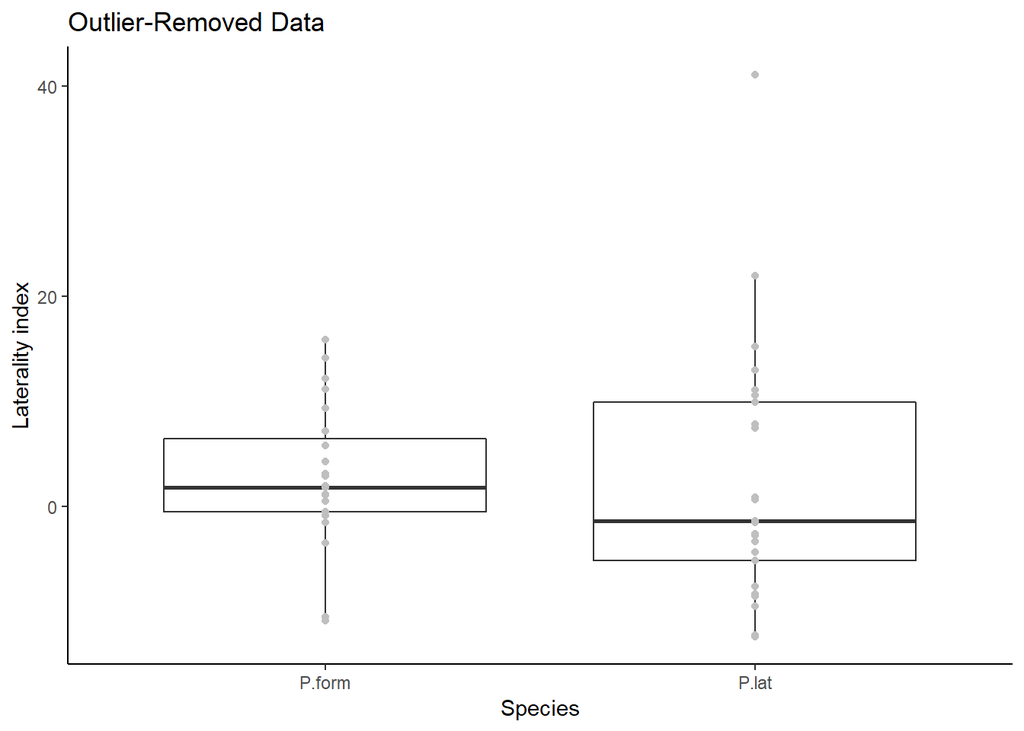

```r
library(ggplot2)
library(ggsignif)
library(gridExtra)
library(ggthemes)


rem_out2 <- ggplot(rawextra, aes(x=X.U.FEFF.SPP, y=LI.TOT)) + geom_boxplot() + geom_point(color="gray75") + xlab("Species") + ylab("Laterality index") + ggtitle("Outlier-Removed Data") + theme_classic()

rem_out2
```

```r
orig2
```

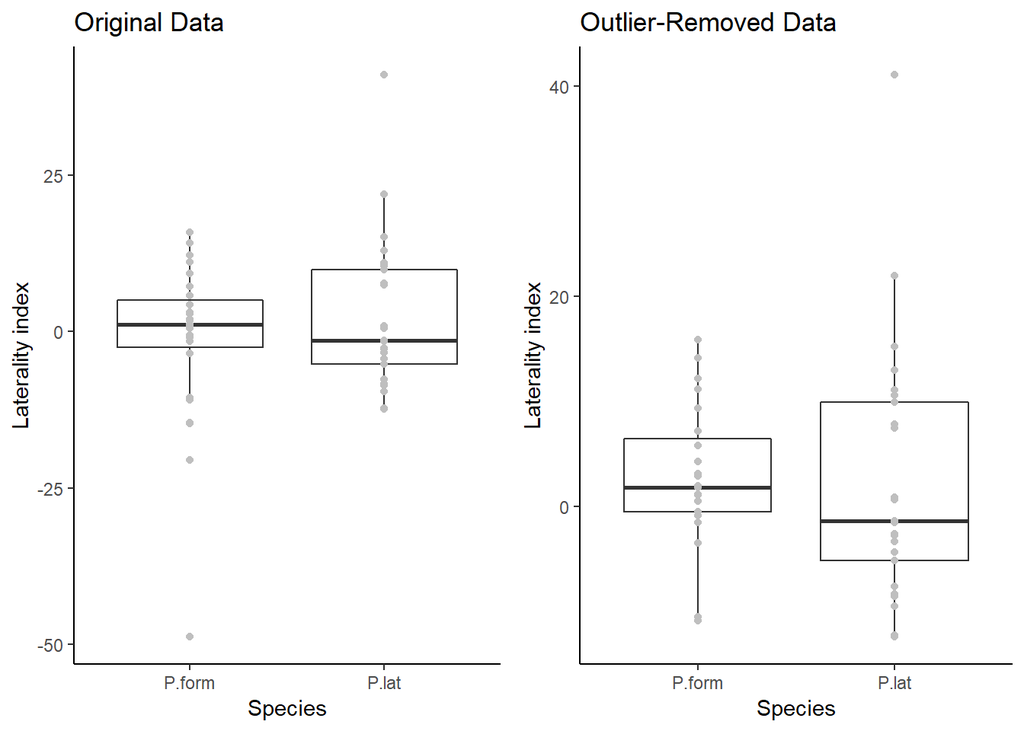

```r
grid.arrange(orig2, rem_out2, ncol=2)
```

Wilcox tests

- tank differences: none

```r
wilcox.test(PROP~TANK, data = tankextra, paired=TRUE, conf.int=TRUE, conf.level=0.95)
```

```
##
##  Wilcoxon signed rank test
##
## data:  PROP by TANK
## V = 497, p-value = 0.3565
## alternative hypothesis: true location shift is not equal to 0
## 95 percent confidence interval:
##  -0.03957066  0.01690745
## sample estimates:
## (pseudo)median
##    -0.01200268
```

```r
wilcox.test(PROP~TANK, data = LAT_tankEX, paired=TRUE, conf.int=TRUE, conf.level=0.95)
```

```
##
##  Wilcoxon signed rank test
##
## data:  PROP by TANK
## V = 139, p-value = 0.5424
## alternative hypothesis: true location shift is not equal to 0
## 95 percent confidence interval:
##  -0.05620011  0.03589071
## sample estimates:
## (pseudo)median
##    -0.01129905
```

```r
wilcox.test(PROP~TANK, data = FORM_tankextra, paired=TRUE, conf.int=TRUE, conf.level=0.95)
```

```
##
##  Wilcoxon signed rank test
##
## data:  PROP by TANK
## V = 110, p-value = 0.41
## alternative hypothesis: true location shift is not equal to 0
## 95 percent confidence interval:
##  -0.04912462  0.02446027
## sample estimates:
## (pseudo)median
##    -0.01301821
```

```r
#using laterality index instead
wilcox.test(LI.TOT~TANK, data = LAT_tankEX, paired=TRUE, conf.int=TRUE, conf.level=0.95)
```

```
##
##  Wilcoxon signed rank test
##
## data:  LI.TOT by TANK
## V = 139, p-value = 0.5424
## alternative hypothesis: true location shift is not equal to 0
## 95 percent confidence interval:
##  -11.240023   7.178141
## sample estimates:
## (pseudo)median
##      -2.259809
```

```r
wilcox.test(LI.TOT~TANK, data = FORM_tankextra, paired=TRUE, conf.int=TRUE, conf.level=0.95)
```

```
##
##  Wilcoxon signed rank test
##
## data:  LI.TOT by TANK
## V = 110, p-value = 0.41
## alternative hypothesis: true location shift is not equal to 0
## 95 percent confidence interval:
##  -9.824923  4.892055
## sample estimates:
## (pseudo)median
##      -2.603641
```

```r
wilcox.test(LI.TOT~TANK, data = FORM_tankEX, paired=TRUE, conf.int=TRUE, conf.level=0.95)
```

```
##
##  Wilcoxon signed rank test
##
## data:  LI.TOT by TANK
## V = 141, p-value = 0.2584
## alternative hypothesis: true location shift is not equal to 0
## 95 percent confidence interval:
##  -12.272161   3.387123
## sample estimates:
## (pseudo)median
##      -3.836368
```

- eye preferences: none for sailfin; 0.025 p for amazon

```r
wilcox.test(LAT_rawEX$TOT.PROP, mu=0.5, alternative = "two.sided", conf.int=TRUE, conf.level=0.95)
```

```
##
##  Wilcoxon signed rank test
##
## data:  LAT_rawEX$TOT.PROP
## V = 178, p-value = 0.6915
## alternative hypothesis: true location is not equal to 0.5
## 95 percent confidence interval:
##  0.4829877 0.5288773
## sample estimates:
## (pseudo)median
##      0.5054374
```

```r
wilcox.test(LAT_rawEX$LI.TOT, mu=0, alternative = "two.sided", conf.int=TRUE, conf.level=0.95)
```

```
##
##  Wilcoxon signed rank test
##
## data:  LAT_rawEX$LI.TOT
## V = 178, p-value = 0.6915
## alternative hypothesis: true location is not equal to 0
## 95 percent confidence interval:
##  -3.402460  5.775465
## sample estimates:
## (pseudo)median
##       1.087489
```

```r
wilcox.test(FORM_rawextra$TOT.PROP, mu=0.5, alternative = "two.sided", conf.int=TRUE, conf.level=0.95)
```

```
##
##  Wilcoxon signed rank test
##
## data:  FORM_rawextra$TOT.PROP
## V = 211, p-value = 0.02542
## alternative hypothesis: true location is not equal to 0.5
## 95 percent confidence interval:
##  0.5013451 0.5305046
## sample estimates:
## (pseudo)median
##      0.5122175
```

```r
wilcox.test(FORM_rawextra$LI.TOT, mu=0, alternative = "two.sided", conf.int=TRUE, conf.level=0.95)
```

```
##
##  Wilcoxon signed rank test
##
## data:  FORM_rawextra$LI.TOT
## V = 211, p-value = 0.02542
## alternative hypothesis: true location is not equal to 0
## 95 percent confidence interval:
##  0.2690259 6.1009299
## sample estimates:
## (pseudo)median
##       2.443493
```

- eye differences: none

```r
wilcox.test(TOT.PROP~X.U.FEFF.SPP, data = rawextra, paired=FALSE, alternative = "two.sided", conf.int=TRUE, conf.level=0.95)
```

```
##
##  Wilcoxon rank sum test
##
## data:  TOT.PROP by X.U.FEFF.SPP
## W = 341, p-value = 0.2768
## alternative hypothesis: true location shift is not equal to 0
## 95 percent confidence interval:
##  -0.01603967  0.03522470
## sample estimates:
## difference in location
##             0.01204981
```

```r
wilcox.test(LI.TOT~X.U.FEFF.SPP, data = rawextra, paired=FALSE, alternative = "two.sided", conf.int=TRUE, conf.level=0.95)
```

```
##
##  Wilcoxon rank sum test
##
## data:  LI.TOT by X.U.FEFF.SPP
## W = 341, p-value = 0.2768
## alternative hypothesis: true location shift is not equal to 0
## 95 percent confidence interval:
##  -3.207935  7.044939
## sample estimates:
## difference in location
##               2.409961
```

- overall laterality

```r
totLAT <- abs(LAT_rawEX$LI.TOT)
totFORM <- abs(FORM_rawextra$LI.TOT)

wilcox.test(totLAT, totFORM, paired = FALSE, alternative = "two.sided", conf.int = TRUE, conf.level = 0.95)
```

```
##
##  Wilcoxon rank sum test
##
## data:  totLAT and totFORM
## W = 364, p-value = 0.1174
## alternative hypothesis: true location shift is not equal to 0
## 95 percent confidence interval:
##  -0.4498884  6.4287229
## sample estimates:
## difference in location
##               2.140738
```

T- tests using LI instead of total proportion

- tank differences: still none

```r
t.test(LAT_rawEX$LI.A, LAT_rawEX$LI.B, paired = TRUE, alternative = "two.sided")
```

```
##
##  Paired t-test
##
## data:  LAT_rawEX$LI.A and LAT_rawEX$LI.B
## t = -0.51597, df = 24, p-value = 0.6106
## alternative hypothesis: true difference in means is not equal to 0
## 95 percent confidence interval:
##  -11.669385   7.001631
## sample estimates:
## mean of the differences
##               -2.333877
```

```r
t.test(FORM_rawextra$LI.A, FORM_rawextra$LI.B, paired = TRUE, alternative = "two.sided")
```

```
##
##  Paired t-test
##
## data:  FORM_rawextra$LI.A and FORM_rawextra$LI.B
## t = -0.59289, df = 22, p-value = 0.5593
## alternative hypothesis: true difference in means is not equal to 0
## 95 percent confidence interval:
##  -10.193180   5.660739
## sample estimates:
## mean of the differences
##                -2.26622
```

- eye preferences: sailfin still no pref, amazon with pretty much no pref (p=0.055)

```r
t.test(LAT_rawEX$LI.TOT, mu=0, alternative = "two.sided")
```

```
##
##  One Sample t-test
##
## data:  LAT_rawEX$LI.TOT
## t = 0.98809, df = 24, p-value = 0.333
## alternative hypothesis: true mean is not equal to 0
## 95 percent confidence interval:
##  -2.617137  7.424639
## sample estimates:
## mean of x
##  2.403751
```

```r
t.test(FORM_rawextra$LI.TOT, mu=0, alternative = "two.sided")
```

```
##
##  One Sample t-test
##
## data:  FORM_rawextra$LI.TOT
## t = 2.0299, df = 22, p-value = 0.05463
## alternative hypothesis: true mean is not equal to 0
## 95 percent confidence interval:
##  -0.0618892  5.7790752
## sample estimates:
## mean of x
##  2.858593
```

- differences between spp: no differences

```r
t.test(LAT_rawEX$LI.TOT, FORM_rawextra$LI.TOT)
```

```
##
##  Welch Two Sample t-test
##
## data:  LAT_rawEX$LI.TOT and FORM_rawextra$LI.TOT
## t = -0.16181, df = 38.111, p-value = 0.8723
## alternative hypothesis: true difference in means is not equal to 0
## 95 percent confidence interval:
##  -6.144693  5.235009
## sample estimates:
## mean of x mean of y
##  2.403751  2.858593
```

- Variance: still significant

```r
var.test(LAT_rawEX$LI.TOT, FORM_rawextra$LI.TOT, alternative = "two.sided")
```

```
##
##  F test to compare two variances
##
## data:  LAT_rawEX$LI.TOT and FORM_rawextra$LI.TOT
## F = 3.2438, num df = 24, denom df = 22, p-value = 0.007199
## alternative hypothesis: true ratio of variances is not equal to 1
## 95 percent confidence interval:
##  1.391286 7.447418
## sample estimates:
## ratio of variances
##           3.243782
```

Transformations

19 AUG 2020: realized I was using the wrong value in the var test (was using just the lat index instead of the arcTOT (which was the arcsin transformed lat index values)). Because the arcsin test produced NAs for the laterality index, the variance was non-significant. To use arcsin transformation, all values must fall between 0 and 1. Will try a log transformation. The log of 0 and any negative number is undefined, so I will have to add a constant to all values, but to my understanding there is no upper limit.

- log transformation

```r
min(FORM_rawextra$LI.TOT) #-15.88448; will add 16 to all values
```

```
## [1] -10.87344
```

```r
min(LAT_rawEX$LI.TOT) #-41.13208; will add 42 to all values
```

```
## [1] -12.39092
```

```r
PFpos <- function(x) {x+16}
LI_pos_PF <- lapply(FORM_rawextra$LI.TOT, PFpos)
LI_pos_PF <- unlist(LI_pos_PF)
FORM_rawextra <- cbind(FORM_rawextra, LI_pos_PF)

PLpos <- function(x) {x+42}
LI_pos_PL <- lapply(LAT_rawEX$LI.TOT, PLpos)
LI_pos_PL <- unlist(LI_pos_PL)
LAT_rawEX <- cbind(LAT_rawEX, LI_pos_PL)

PL_trans4 <- transform(LAT_rawEX, LOG = log(LAT_rawEX$LI_pos_PL))

PF_trans4 <- transform(FORM_rawextra, LOG = log(FORM_rawextra$LI_pos_PF))

var.test(PL_trans4$LOG, PF_trans4$LOG, alternative = "two.sided")
```

```
##
##  F test to compare two variances
##
## data:  PL_trans4$LOG and PF_trans4$LOG
## F = 0.30872, num df = 24, denom df = 22, p-value = 0.006158
## alternative hypothesis: true ratio of variances is not equal to 1
## 95 percent confidence interval:
##  0.1324137 0.7087975
## sample estimates:
## ratio of variances
##          0.3087224
```

```r
var.test(PL_trans4$LOG, PF_trans4$LOG, alternative = "greater")
```

```
##
##  F test to compare two variances
##
## data:  PL_trans4$LOG and PF_trans4$LOG
## F = 0.30872, num df = 24, denom df = 22, p-value = 0.9969
## alternative hypothesis: true ratio of variances is greater than 1
## 95 percent confidence interval:
##  0.1522061       Inf
## sample estimates:
## ratio of variances
##          0.3087224
```

```r
var.test(PL_trans4$LOG, PF_trans4$LOG, alternative = "less")
```

```
##
##  F test to compare two variances
##
## data:  PL_trans4$LOG and PF_trans4$LOG
## F = 0.30872, num df = 24, denom df = 22, p-value = 0.003079
## alternative hypothesis: true ratio of variances is less than 1
## 95 percent confidence interval:
##  0.0000000 0.6185197
## sample estimates:
## ratio of variances
##          0.3087224
```

```r
PL_trans5 <- transform(LAT_rawEX, LOG = log(LAT_rawEX$TOT.PROP))

PF_trans5 <- transform(FORM_rawextra, LOG = log(FORM_rawextra$TOT.PROP))

var.test(PL_trans5$LOG, PF_trans5$LOG, alternative = "two.sided")
```

```
##
##  F test to compare two variances
##
## data:  PL_trans5$LOG and PF_trans5$LOG
## F = 2.8745, num df = 24, denom df = 22, p-value = 0.01532
## alternative hypothesis: true ratio of variances is not equal to 1
## 95 percent confidence interval:
##  1.232902 6.599606
## sample estimates:
## ratio of variances
##           2.874511
```

```r
var.test(PL_trans5$LOG, PF_trans5$LOG, alternative = "greater")
```

```
##
##  F test to compare two variances
##
## data:  PL_trans5$LOG and PF_trans5$LOG
## F = 2.8745, num df = 24, denom df = 22, p-value = 0.007662
## alternative hypothesis: true ratio of variances is greater than 1
## 95 percent confidence interval:
##  1.417189      Inf
## sample estimates:
## ratio of variances
##           2.874511
```

```r
var.test(PL_trans5$LOG, PF_trans5$LOG, alternative = "less")
```

```
##
##  F test to compare two variances
##
## data:  PL_trans5$LOG and PF_trans5$LOG
## F = 2.8745, num df = 24, denom df = 22, p-value = 0.9923
## alternative hypothesis: true ratio of variances is less than 1
## 95 percent confidence interval:
##  0.00000 5.75903
## sample estimates:
## ratio of variances
##           2.874511
```

- transform the data WITH LAT INDEX

```r
PL_trans3 <- transform(LAT_rawEX, arcTOT = asin(LAT_rawEX$LI.TOT))
PF_trans3 <- transform(FORM_rawextra, arcTOT = asin(FORM_rawextra$LI.TOT))
```

- variance WITH LAT INDEX: p is .007; **arcTOT is not significant because of NAs produced

```r
var.test(PL_trans3$arcTOT, PF_trans3$arcTOT, alternative = "two.sided")
```

```
##
##  F test to compare two variances
##
## data:  PL_trans3$arcTOT and PF_trans3$arcTOT
## F = 0.086467, num df = 2, denom df = 3, p-value = 0.1613
## alternative hypothesis: true ratio of variances is not equal to 1
## 95 percent confidence interval:
##  0.005389332 3.386523293
## sample estimates:
## ratio of variances
##         0.08646701
```

```r
var.test(PL_trans3$arcTOT, PF_trans3$arcTOT, alternative = "greater")
```

```
##
##  F test to compare two variances
##
## data:  PL_trans3$arcTOT and PF_trans3$arcTOT
## F = 0.086467, num df = 2, denom df = 3, p-value = 0.9194
## alternative hypothesis: true ratio of variances is greater than 1
## 95 percent confidence interval:
##  0.009052152         Inf
## sample estimates:
## ratio of variances
##         0.08646701
```

```r
var.test(PL_trans3$arcTOT, PF_trans3$arcTOT, alternative = "less")
```

```
##
##  F test to compare two variances
##
## data:  PL_trans3$arcTOT and PF_trans3$arcTOT
## F = 0.086467, num df = 2, denom df = 3, p-value = 0.08063
## alternative hypothesis: true ratio of variances is less than 1
## 95 percent confidence interval:
##  0.000000 1.657079
## sample estimates:
## ratio of variances
##         0.08646701
```

- transform the data

```r
PL_transA2 <- transform(LAT_rawEX, arcA = asin(LAT_rawEX$A.PROP))

PF_transA2 <- transform(FORM_rawextra, arcA = asin(FORM_rawextra$A.PROP))


PL_transB2 <- transform(LAT_rawEX, arcB = asin(LAT_rawEX$B.PROP))

PF_transB2 <- transform(FORM_rawextra, arcB = asin(FORM_rawextra$B.PROP))


PL_trans2 <- transform(LAT_rawEX, arcTOT2 = asin(LAT_rawEX$TOT.PROP))

PF_trans2 <- transform(FORM_rawextra, arcTOT2 = asin(FORM_rawextra$TOT.PROP))
```

- t-tests: tank differences - still none

```r
t.test(PL_transA2$arcA, PL_transB2$arcB, paired = TRUE, alternative = "two.sided")
```

```
##
##  Paired t-test
##
## data:  PL_transA2$arcA and PL_transB2$arcB
## t = -0.56849, df = 24, p-value = 0.575
## alternative hypothesis: true difference in means is not equal to 0
## 95 percent confidence interval:
##  -0.07238711  0.04112181
## sample estimates:
## mean of the differences
##             -0.01563265
```

```r
t.test(PF_transA2$arcA, PF_transB2$arcB, paired = TRUE, alternative = "two.sided")
```

```
##
##  Paired t-test
##
## data:  PF_transA2$arcA and PF_transB2$arcB
## t = -0.59529, df = 22, p-value = 0.5577
## alternative hypothesis: true difference in means is not equal to 0
## 95 percent confidence interval:
##  -0.06036094  0.03343712
## sample estimates:
## mean of the differences
##             -0.01346191
```

```r
t.test(PL_trans2$TOT.PROP, mu=0.5, alternative = "two.sided")
```

```
##
##  One Sample t-test
##
## data:  PL_trans2$TOT.PROP
## t = 0.98809, df = 24, p-value = 0.333
## alternative hypothesis: true mean is not equal to 0.5
## 95 percent confidence interval:
##  0.4869143 0.5371232
## sample estimates:
## mean of x
## 0.5120188
```

```r
t.test(PF_trans2$TOT.PROP, mu=0.5, alternative = "two.sided")
```

```
##
##  One Sample t-test
##
## data:  PF_trans2$TOT.PROP
## t = 2.0299, df = 22, p-value = 0.05463
## alternative hypothesis: true mean is not equal to 0.5
## 95 percent confidence interval:
##  0.4996906 0.5288954
## sample estimates:
## mean of x
##  0.514293
```

- t-tests: comparing species -still no difference

```r
t.test(PL_trans2$TOT.PROP, PF_trans2$TOT.PROP)
```

```
##
##  Welch Two Sample t-test
##
## data:  PL_trans2$TOT.PROP and PF_trans2$TOT.PROP
## t = -0.16181, df = 38.111, p-value = 0.8723
## alternative hypothesis: true difference in means is not equal to 0
## 95 percent confidence interval:
##  -0.03072347  0.02617505
## sample estimates:
## mean of x mean of y
## 0.5120188 0.5142930
```

```r
var.test(PL_trans2$arcTOT2, PF_trans2$arcTOT2, alternative = "two.sided")
```

```
##
##  F test to compare two variances
##
## data:  PL_trans2$arcTOT2 and PF_trans2$arcTOT2
## F = 3.4874, num df = 24, denom df = 22, p-value = 0.004469
## alternative hypothesis: true ratio of variances is not equal to 1
## 95 percent confidence interval:
##  1.495776 8.006745
## sample estimates:
## ratio of variances
##           3.487402
```

```r
var.test(PL_trans2$TOT.PROP, PF_trans2$TOT.PROP, alternative = "greater")
```

```
##
##  F test to compare two variances
##
## data:  PL_trans2$TOT.PROP and PF_trans2$TOT.PROP
## F = 3.2438, num df = 24, denom df = 22, p-value = 0.0036
## alternative hypothesis: true ratio of variances is greater than 1
## 95 percent confidence interval:
##  1.599247      Inf
## sample estimates:
## ratio of variances
##           3.243782
```

```r
var.test(PL_trans2$TOT.PROP, PF_trans2$TOT.PROP, alternative = "less")
```

```
##
##  F test to compare two variances
##
## data:  PL_trans2$TOT.PROP and PF_trans2$TOT.PROP
## F = 3.2438, num df = 24, denom df = 22, p-value = 0.9964
## alternative hypothesis: true ratio of variances is less than 1
## 95 percent confidence interval:
##  0.000000 6.498858
## sample estimates:
## ratio of variances
##           3.243782
```

#### Outlier tests

Histogram shows what appear to be outliers in both species. Will now perform a Tukey’s outlier test to see if they are in fact outlier, and if removing these outliers changes the variance between species.

```
## integer(0)
```

```
## integer(0)
```

- Sailfin: no outliers

```
## [1]  2  3 11 19
```

- Amazons: outliers at row 2, 3, 11, 19

```r
(PF_outliers <- p_formRE[c(2,3,11,19),])
```

```
##    X.U.FEFF.SPP     NAME     A.PROP    B.PROP  TOT.PROP  AVG.PROP
## 22       Amazon    Maeve 0.45744681 0.4354839 0.4471698 0.4464653
## 23       Amazon  Cayenne 0.46315789 0.3321678 0.3975482 0.3976629
## 31       Amazon Gretchen 0.01689189 0.5017301 0.2564103 0.2593110
## 39       Amazon    Sofia 0.37457045 0.4793103 0.4268503 0.4269404
```

Looks like there are four outlier in the formosa data, but no outliers in the latipinna data.

#### T-tests

I will create a new dataframe without these rows, and test for eye preference and compare variation again.

- t-test for eye preference
  - Amazons:

```
##
##  One Sample t-test
##
## data:  PFORM_RE$TOT.PROP
## t = 2.5322, df = 15, p-value = 0.02299
## alternative hypothesis: true mean is not equal to 0.5
## 95 percent confidence interval:
##  0.5028851 0.5335741
## sample estimates:
## mean of x
## 0.5182296
```

- Sailfins

```
##
##  One Sample t-test
##
## data:  p_latRE$TOT.PROP
## t = 0.83192, df = 19, p-value = 0.4158
## alternative hypothesis: true mean is not equal to 0.5
## 95 percent confidence interval:
##  0.4814764 0.5429627
## sample estimates:
## mean of x
## 0.5122196
```

```
##
##  One Sample t-test
##
## data:  p_latRE$AVG.PROP
## t = 0.83305, df = 19, p-value = 0.4152
## alternative hypothesis: true mean is not equal to 0.5
## 95 percent confidence interval:
##  0.4819459 0.5419274
## sample estimates:
## mean of x
## 0.5119366
```

Amazons show left-eye bias, but sailfins show no eye bias.

- comparing species
  - means

```
##
##  Welch Two Sample t-test
##
## data:  p_latRE$TOT.PROP and PFORM_RE$TOT.PROP
## t = -0.36741, df = 27.234, p-value = 0.7162
## alternative hypothesis: true difference in means is not equal to 0
## 95 percent confidence interval:
##  -0.03955983  0.02753982
## sample estimates:
## mean of x mean of y
## 0.5122196 0.5182296
```

```
##
##  Welch Two Sample t-test
##
## data:  p_latRE$AVG.PROP and PFORM_RE$TOT.PROP
## t = -0.39243, df = 27.577, p-value = 0.6978
## alternative hypothesis: true difference in means is not equal to 0
## 95 percent confidence interval:
##  -0.03916337  0.02657750
## sample estimates:
## mean of x mean of y
## 0.5119366 0.5182296
```

The species don’t significantly differ in average eye use.

#### Wilcox tests

Since we’re dealing with proportions, I will use Wilcox signed rank and rank sum tests to re-analyze the data

- Tank differences

```r
library(curl)

rawTANKS <- curl("https://raw.githubusercontent.com/allisondavis/mirror-exp_wild-pop/master/adavis_mirrorexp-tanks.csv")

rawTANKS <- read.csv(rawTANKS, header = TRUE, sep = ",", stringsAsFactors = TRUE)

wilcox.test(PROP~TANK, data = rawTANKS, paired=TRUE)
```

```
##
##  Wilcoxon signed rank test
##
## data:  PROP by TANK
## V = 322, p-value = 0.2424
## alternative hypothesis: true location shift is not equal to 0
```

```r
FrawTANKS <- rawTANKS[rawTANKS$X.U.FEFF.SPP == "P.form",]
LrawTANKS <- rawTANKS[rawTANKS$X.U.FEFF.SPP == "P.lat", ]

wilcox.test(PROP~TANK, data = FrawTANKS, paired=TRUE, conf.int=TRUE, conf.level=0.95)
```

```
##
##  Wilcoxon signed rank test
##
## data:  PROP by TANK
## V = 85, p-value = 0.4749
## alternative hypothesis: true location shift is not equal to 0
## 95 percent confidence interval:
##  -0.05783129  0.03008283
## sample estimates:
## (pseudo)median
##    -0.01537065
```

```r
wilcox.test(PROP~TANK, data = LrawTANKS, paired=TRUE, conf.int=TRUE, conf.level=0.95)
```

```
##
##  Wilcoxon signed rank test
##
## data:  PROP by TANK
## V = 78, p-value = 0.33
## alternative hypothesis: true location shift is not equal to 0
## 95 percent confidence interval:
##  -0.06902255  0.03088646
## sample estimates:
## (pseudo)median
##    -0.01961612
```

```r
#want to make sure outliers don't change this; Form outliers: Maeve, Cayenne, Gretchen, Sofia

FrawTANKS_out <- FrawTANKS[-c(3,4,5,6,21,22,37,38),]
wilcox.test(PROP~TANK, data = FrawTANKS_out, paired=TRUE, conf.int=TRUE, conf.level=0.95)
```

```
##
##  Wilcoxon signed rank test
##
## data:  PROP by TANK
## V = 55, p-value = 0.5282
## alternative hypothesis: true location shift is not equal to 0
## 95 percent confidence interval:
##  -0.04935638  0.03294908
## sample estimates:
## (pseudo)median
##    -0.01211761
```

No differences between the tanks, so I can analyze with total proportion.

- Eye preference
- Amazons:

```
##
##  Wilcoxon signed rank test
##
## data:  PFORM_RE$TOT.PROP
## V = 114, p-value = 0.0155
## alternative hypothesis: true location is not equal to 0.5
## 95 percent confidence interval:
##  0.5016205 0.5356585
## sample estimates:
## (pseudo)median
##      0.5105547
```

- Sailfins

```
##
##  Wilcoxon signed rank test
##
## data:  p_latRE$TOT.PROP
## V = 112, p-value = 0.8124
## alternative hypothesis: true location is not equal to 0.5
## 95 percent confidence interval:
##  0.4782609 0.5340690
## sample estimates:
## (pseudo)median
##      0.5041075
```

```
##
##  Wilcoxon signed rank test
##
## data:  p_latRE$AVG.PROP
## V = 112, p-value = 0.8124
## alternative hypothesis: true location is not equal to 0.5
```

Amazons still have left-eye bias and sailfins still have no eye bias.

- comparing species

```r
raw2 <- rbind(p_latRE, PFORM_RE)

wilcox.test(TOT.PROP~X.U.FEFF.SPP, data = raw2, paired=FALSE, alternative = "two.sided", conf.int=TRUE, conf.level=0.95)
```

```
##
##  Wilcoxon rank sum test
##
## data:  TOT.PROP by X.U.FEFF.SPP
## W = 208, p-value = 0.1317
## alternative hypothesis: true location shift is not equal to 0
## 95 percent confidence interval:
##  -0.009622643  0.043266639
## sample estimates:
## difference in location
##             0.01886005
```

```r
#the confidence interval includes 0, illustrating further a lack of significant difference between the medians
```

Species still don’t significantly differ in average eye use.

#### Variance

variances: two-sided (either spp variance greater or less)

```
##
##  F test to compare two variances
##
## data:  p_latRE$TOT.PROP and PFORM_RE$TOT.PROP
## F = 5.2036, num df = 19, denom df = 15, p-value = 0.002202
## alternative hypothesis: true ratio of variances is not equal to 1
## 95 percent confidence interval:
##   1.876498 13.618433
## sample estimates:
## ratio of variances
##             5.2036
```

```
##
##  F test to compare two variances
##
## data:  p_latRE$AVG.PROP and PFORM_RE$TOT.PROP
## F = 4.952, num df = 19, denom df = 15, p-value = 0.002895
## alternative hypothesis: true ratio of variances is not equal to 1
## 95 percent confidence interval:
##   1.785774 12.960015
## sample estimates:
## ratio of variances
##           4.952018
```

- variances: greater (p.lat variance > p.form)

```
##
##  F test to compare two variances
##
## data:  p_latRE$TOT.PROP and PFORM_RE$TOT.PROP
## F = 5.2036, num df = 19, denom df = 15, p-value = 0.001101
## alternative hypothesis: true ratio of variances is greater than 1
## 95 percent confidence interval:
##  2.223932      Inf
## sample estimates:
## ratio of variances
##             5.2036
```

```
##
##  F test to compare two variances
##
## data:  p_latRE$AVG.PROP and PFORM_RE$TOT.PROP
## F = 4.952, num df = 19, denom df = 15, p-value = 0.001447
## alternative hypothesis: true ratio of variances is greater than 1
## 95 percent confidence interval:
##  2.116411      Inf
## sample estimates:
## ratio of variances
##           4.952018
```

- variances: lesser(p.lat variance < p.form)

```
##
##  F test to compare two variances
##
## data:  p_latRE$TOT.PROP and PFORM_RE$TOT.PROP
## F = 5.2036, num df = 19, denom df = 15, p-value = 0.9989
## alternative hypothesis: true ratio of variances is less than 1
## 95 percent confidence interval:
##   0.00000 11.62517
## sample estimates:
## ratio of variances
##             5.2036
```

```
##
##  F test to compare two variances
##
## data:  p_latRE$AVG.PROP and PFORM_RE$TOT.PROP
## F = 4.952, num df = 19, denom df = 15, p-value = 0.9986
## alternative hypothesis: true ratio of variances is less than 1
## 95 percent confidence interval:
##   0.00000 11.06312
## sample estimates:
## ratio of variances
##           4.952018
```

#### Transformations

Since the preference is a proportion, parametric tests may be the incorrect form of analyses. While there is a non-parametric alternative to the t-test (Wilcox tests), I cannot seem to find an alterantive to the F-test. Upon Mike’s suggestion, I’ll do an arcsine transformation on the total proportion data. I will then re-run the t-tests and F-tests with this new data.

- transform the data

```r
PL_transA <- transform(p_latRE, arcA = asin(p_latRE$A.PROP))

PF_transA <- transform(PFORM_RE, arcA = asin(PFORM_RE$A.PROP))


PL_transB <- transform(p_latRE, arcB = asin(p_latRE$B.PROP))

PF_transB <- transform(PFORM_RE, arcB = asin(PFORM_RE$B.PROP))


PL_trans <- transform(p_latRE, arcTOT = asin(p_latRE$TOT.PROP))

PF_trans <- transform(PFORM_RE, arcTOT = asin(PFORM_RE$TOT.PROP))
```

- t-tests: tank differences

```r
t.test(PL_transA$arcA, PL_transB$arcB, paired = TRUE, alternative = "two.sided")
```

```
##
##  Paired t-test
##
## data:  PL_transA$arcA and PL_transB$arcB
## t = -0.89858, df = 19, p-value = 0.3801
## alternative hypothesis: true difference in means is not equal to 0
## 95 percent confidence interval:
##  -0.09207910  0.03676391
## sample estimates:
## mean of the differences
##             -0.02765759
```

```r
t.test(PF_transA$arcA, PF_transB$arcB, paired = TRUE, alternative = "two.sided")
```

```
##
##  Paired t-test
##
## data:  PF_transA$arcA and PF_transB$arcB
## t = -0.36857, df = 15, p-value = 0.7176
## alternative hypothesis: true difference in means is not equal to 0
## 95 percent confidence interval:
##  -0.05394144  0.03803647
## sample estimates:
## mean of the differences
##            -0.007952484
```

Still no differences between the tanks.

- t-tests: eye preference

```r
t.test(PL_trans$TOT.PROP, mu=0.5, alternative = "two.sided")
```

```
##
##  One Sample t-test
##
## data:  PL_trans$TOT.PROP
## t = 0.83192, df = 19, p-value = 0.4158
## alternative hypothesis: true mean is not equal to 0.5
## 95 percent confidence interval:
##  0.4814764 0.5429627
## sample estimates:
## mean of x
## 0.5122196
```

```r
t.test(PF_trans$TOT.PROP, mu=0.5, alternative = "two.sided")
```

```
##
##  One Sample t-test
##
## data:  PF_trans$TOT.PROP
## t = 2.5322, df = 15, p-value = 0.02299
## alternative hypothesis: true mean is not equal to 0.5
## 95 percent confidence interval:
##  0.5028851 0.5335741
## sample estimates:
## mean of x
## 0.5182296
```

Sailfin still with no significant eye preference, and amazon with significant left-eye bias.

- t-tests: comparing species

```r
t.test(PL_trans$TOT.PROP, PF_trans$TOT.PROP)
```

```
##
##  Welch Two Sample t-test
##
## data:  PL_trans$TOT.PROP and PF_trans$TOT.PROP
## t = -0.36741, df = 27.234, p-value = 0.7162
## alternative hypothesis: true difference in means is not equal to 0
## 95 percent confidence interval:
##  -0.03955983  0.02753982
## sample estimates:
## mean of x mean of y
## 0.5122196 0.5182296
```

Still no difference in average eye use between the species.

- variance:

```r
var.test(PL_trans$TOT.PROP, PF_trans$TOT.PROP, alternative = "two.sided")
```

```
##
##  F test to compare two variances
##
## data:  PL_trans$TOT.PROP and PF_trans$TOT.PROP
## F = 5.2036, num df = 19, denom df = 15, p-value = 0.002202
## alternative hypothesis: true ratio of variances is not equal to 1
## 95 percent confidence interval:
##   1.876498 13.618433
## sample estimates:
## ratio of variances
##             5.2036
```

```r
var.test(PL_trans$TOT.PROP, PF_trans$TOT.PROP, alternative = "greater")
```

```
##
##  F test to compare two variances
##
## data:  PL_trans$TOT.PROP and PF_trans$TOT.PROP
## F = 5.2036, num df = 19, denom df = 15, p-value = 0.001101
## alternative hypothesis: true ratio of variances is greater than 1
## 95 percent confidence interval:
##  2.223932      Inf
## sample estimates:
## ratio of variances
##             5.2036
```

```r
var.test(PL_trans$TOT.PROP, PF_trans$TOT.PROP, alternative = "less")
```

```
##
##  F test to compare two variances
##
## data:  PL_trans$TOT.PROP and PF_trans$TOT.PROP
## F = 5.2036, num df = 19, denom df = 15, p-value = 0.9989
## alternative hypothesis: true ratio of variances is less than 1
## 95 percent confidence interval:
##   0.00000 11.62517
## sample estimates:
## ratio of variances
##             5.2036
```

Sailfin still with significantly more variation than amazons.

#### Fisher’s exact test

This test can calculate differences in proportion for small sample sizes (n<30). It takes the raw values though, not the proportions. Will need to make a contingency table.

In addition I can perform an exact binomial test to see if the proportions within each species are significantly different than 0.5 (determining eye bias).

rawFISH <- raw[-c(22,23,31,39),]

fisher.test(rawFISH$X.U.FEFF.SPP, rawFISH$TOT.LEFT, alternative = “two.sided”, conf.int = TRUE)

fisher.test(rawFISH$X.U.FEFF.SPP, rawFISH$TOT.RIGHT, alternative = “two.sided”, conf.int = TRUE)

fisher’s test says left eye between species is not significant (nor is right eye), which is what my other tests showed

FRAW <- rawFISH[c(21:40) , c(1,11)] sum(FRAW$TOT.LEFT, na.rm = TRUE) binom.test(x=3275, n=9472, p=0.5)

LRAW <- rawFISH[c(1:20) , c(1,11)] sum(LRAW$TOT.LEFT) binom.test(x=4511, n=11840, p=0.5) think I’m doing something wrong here, need to come back to it

#### Kruskal-Wallis

From my understanding, the Kruskal-Wallis test is similar to the Mann Whitney U/Wilcox rank sum test in that it is a non-parametric test using ranks of values to test differences in medians between groups. Only difference (I can see) is that Kruskal is used more when comparing 3+ groups, whereas MWU is for 2 groups.

A squared rank test is a non-parametric version of the F-test (I think), in which it is seeing whether the variance/distribution in rank is different between groups. Does a bunch of pairwise comparisons (need to look up more what that means). Often used as a posthoc test after the null is rejected in a Kruskal-Wallis.

Going to try the Kruskal-Wallis and squared rank test on my non-transformed data.

```r
library(PMCMR)
kruskal.test(TOT.PROP~X.U.FEFF.SPP, data = raw2)
```

```
##
##  Kruskal-Wallis rank sum test
##
## data:  TOT.PROP by X.U.FEFF.SPP
## Kruskal-Wallis chi-squared = 2.3351, df = 1, p-value = 0.1265
```

```r
posthoc.kruskal.conover.test(TOT.PROP~X.U.FEFF.SPP, data = raw2)
```

```
##
##  Pairwise comparisons using Conover's-test for multiple
##                          comparisons of independent samples
##
## data:  TOT.PROP by X.U.FEFF.SPP
##
##         Amazon
## Sailfin 0.13
##
## P value adjustment method: holm
```

```r
library(conover.test)

conover.test(raw2$TOT.PROP, raw2$X.U.FEFF.SPP, altp = TRUE)
```

```
##   Kruskal-Wallis rank sum test
##
## data: x and group
## Kruskal-Wallis chi-squared = 2.3351, df = 1, p-value = 0.13
##
##
##                            Comparison of x by group
##                                 (No adjustment)
## Col Mean-|
## Row Mean |     Amazon
## ---------+-----------
##  Sailfin |   1.559032
##          |     0.1282
##
## alpha = 0.05
## Reject Ho if p <= alpha
```

Not sure this is giving me what I’m looking for. Seems this p-value is the same as the p-value given with the Mann Whitney U test comparing the species. Don’t think this is then testing for differences in variation.

#### Boxplots

Will create boxplots using both the original, and outlier-removed data

- Will combine the total preference scores of both original and outlier-removed data into one dataset in order to use ggplot more easily.

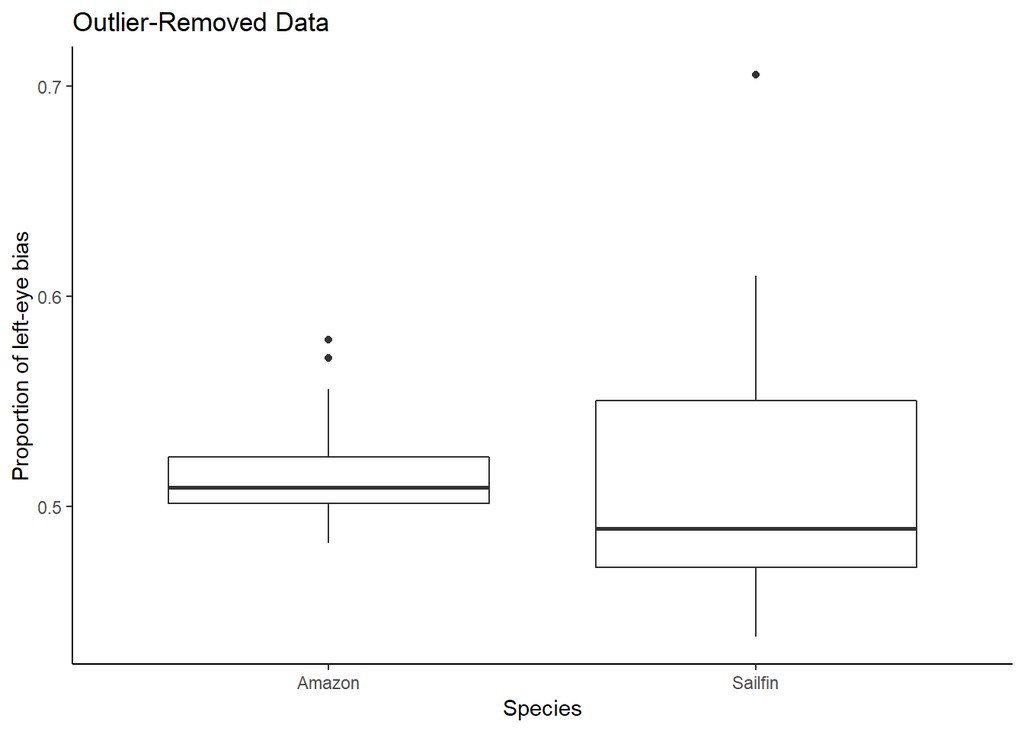

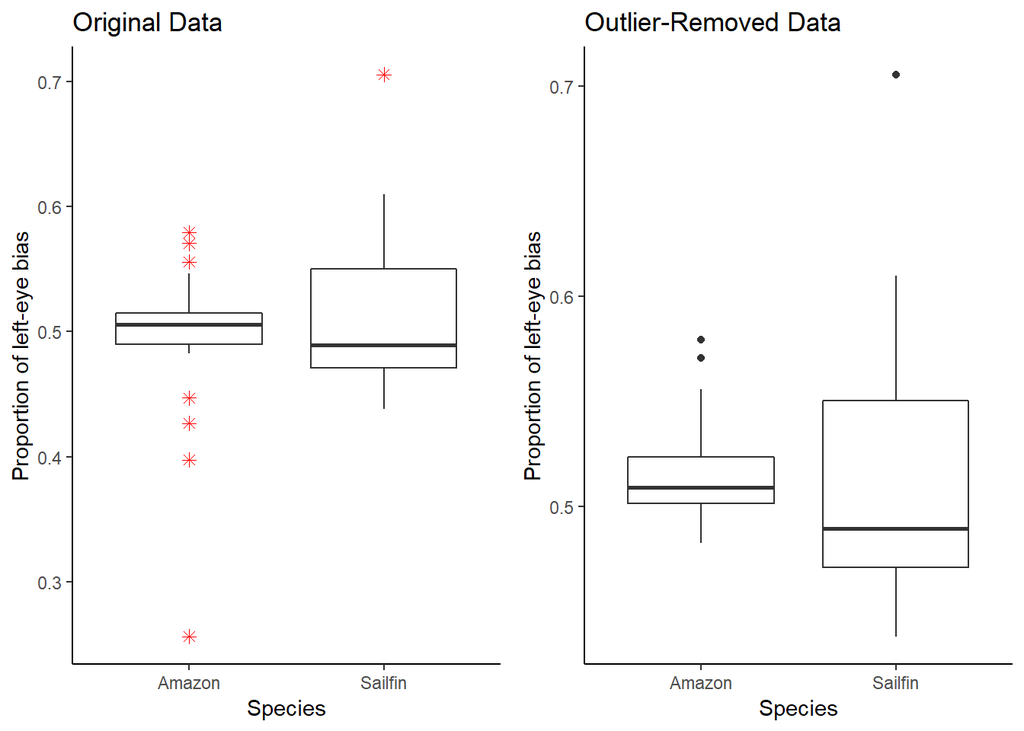

#### Repeatability

Consistency in eye use across trials

Here I will examine if individuals were consistent with their eye preference across the two trials. * Since formosa were the only ones w/lateralized vision, this is more pertinent to them + if they are lateralized, as clones, they should also be consistent in their lateralization across trials. If they are no consistent, this might mean that the significance we see with their lateralized vision, might just be a statistically chance. * would be interesting to see if individuals are still consistent among trials, but overall no spp lateralization for latipinna

I will be using `cor.test(x,y,method="pearson", "kendall", "spearman")` * can also add `use="complete.obs"` if I have missing values

With z-scores of LI data (not sure if this is kosher or useful)

```r
library(tidyverse)

LAT_rawextraP <- LAT_rawextraP %>% mutate(z.LIA = c(scale(LI.A)))

LAT_rawextraP <- LAT_rawextraP %>% mutate(z.LIB = c(scale(LI.B)))

FORM_rawextraP <- FORM_rawextraP %>% mutate(z.LIA = c(scale(LI.A)))

FORM_rawextraP <- FORM_rawextraP %>% mutate(z.LIB = c(scale(LI.B)))
```

```r
library(ggpubr)

cor.test(LAT_rawextraP$z.LIA, LAT_rawextraP$z.LIB, method ="pearson")
```

```
##
##  Pearson's product-moment correlation
##
## data:  LAT_rawextraP$z.LIA and LAT_rawextraP$z.LIB
## t = -0.54497, df = 22, p-value = 0.5913
## alternative hypothesis: true correlation is not equal to 0
## 95 percent confidence interval:
##  -0.4957295  0.3020466
## sample estimates:
##        cor
## -0.1154125
```

```r
cor.test(FORM_rawextraP$z.LIA, FORM_rawextraP$z.LIB, method = "pearson")
```

```
##
##  Pearson's product-moment correlation
##
## data:  FORM_rawextraP$z.LIA and FORM_rawextraP$z.LIB
## t = -0.58651, df = 23, p-value = 0.5632
## alternative hypothesis: true correlation is not equal to 0
## 95 percent confidence interval:
##  -0.4928818  0.2875302
## sample estimates:
##        cor
## -0.1213924
```

With raw LI data

```r
library(ggpubr)

cor.test(LAT_rawextraP$LI.A, LAT_rawextraP$LI.B, method ="pearson")
```

```
##
##  Pearson's product-moment correlation
##
## data:  LAT_rawextraP$LI.A and LAT_rawextraP$LI.B
## t = -0.54497, df = 22, p-value = 0.5913
## alternative hypothesis: true correlation is not equal to 0
## 95 percent confidence interval:
##  -0.4957295  0.3020466
## sample estimates:
##        cor
## -0.1154125
```

```r
cor.test(FORM_rawextraP$LI.A, FORM_rawextraP$LI.B, method = "pearson")
```

```
##
##  Pearson's product-moment correlation
##
## data:  FORM_rawextraP$LI.A and FORM_rawextraP$LI.B
## t = -0.58651, df = 23, p-value = 0.5632
## alternative hypothesis: true correlation is not equal to 0
## 95 percent confidence interval:
##  -0.4928818  0.2875302
## sample estimates:
##        cor
## -0.1213924
```

With z-scores of LI data (not sure if this is kosher or useful)

```r
library(tidyverse)

LAT_rawextraP <- LAT_rawextraP %>% mutate(z.LIA = c(scale(LI.A)))

LAT_rawextraP <- LAT_rawextraP %>% mutate(z.LIB = c(scale(LI.B)))

FORM_rawextraP <- FORM_rawextraP %>% mutate(z.LIA = c(scale(LI.A)))

FORM_rawextraP <- FORM_rawextraP %>% mutate(z.LIB = c(scale(LI.B)))
```

```r
library(ggpubr)

cor.test(LAT_rawextraP$z.LIA, LAT_rawextraP$z.LIB, method ="pearson")
```

```
##
##  Pearson's product-moment correlation
##
## data:  LAT_rawextraP$z.LIA and LAT_rawextraP$z.LIB
## t = -0.54497, df = 22, p-value = 0.5913
## alternative hypothesis: true correlation is not equal to 0
## 95 percent confidence interval:
##  -0.4957295  0.3020466
## sample estimates:
##        cor
## -0.1154125
```

```r
cor.test(FORM_rawextraP$z.LIA, FORM_rawextraP$z.LIB, method = "pearson")
```

```
##
##  Pearson's product-moment correlation
##
## data:  FORM_rawextraP$z.LIA and FORM_rawextraP$z.LIB
## t = -0.58651, df = 23, p-value = 0.5632
## alternative hypothesis: true correlation is not equal to 0
## 95 percent confidence interval:
##  -0.4928818  0.2875302
## sample estimates:
##        cor
## -0.1213924
```

With raw LI data

```r
library(ggpubr)

cor.test(LAT_rawextraP$LI.A, LAT_rawextraP$LI.B, method ="pearson")
```

```
##
##  Pearson's product-moment correlation
##
## data:  LAT_rawextraP$LI.A and LAT_rawextraP$LI.B
## t = -0.54497, df = 22, p-value = 0.5913
## alternative hypothesis: true correlation is not equal to 0
## 95 percent confidence interval:
##  -0.4957295  0.3020466
## sample estimates:
##        cor
## -0.1154125
```

```r
cor.test(FORM_rawextraP$LI.A, FORM_rawextraP$LI.B, method = "pearson")
```

```
##
##  Pearson's product-moment correlation
##
## data:  FORM_rawextraP$LI.A and FORM_rawextraP$LI.B
## t = -0.58651, df = 23, p-value = 0.5632
## alternative hypothesis: true correlation is not equal to 0
## 95 percent confidence interval:
##  -0.4928818  0.2875302
## sample estimates:
##        cor
## -0.1213924
```

```
##
##  Pearson's product-moment correlation
##
## data:  p_latRE$A.PROP and p_latRE$B.PROP
## t = 0.56708, df = 18, p-value = 0.5777
## alternative hypothesis: true correlation is not equal to 0
## 95 percent confidence interval:
##  -0.3293455  0.5431608
## sample estimates:
##       cor
## 0.1324838
```

```
##
##  Pearson's product-moment correlation
##
## data:  PFORM_RE$A.PROP and PFORM_RE$B.PROP
## t = -0.95061, df = 14, p-value = 0.3579
## alternative hypothesis: true correlation is not equal to 0
## 95 percent confidence interval:
##  -0.6612319  0.2841519
## sample estimates:
##        cor
## -0.2462373
```

Looks like neither correlation is significant. I will visualize using a scatter plot below.

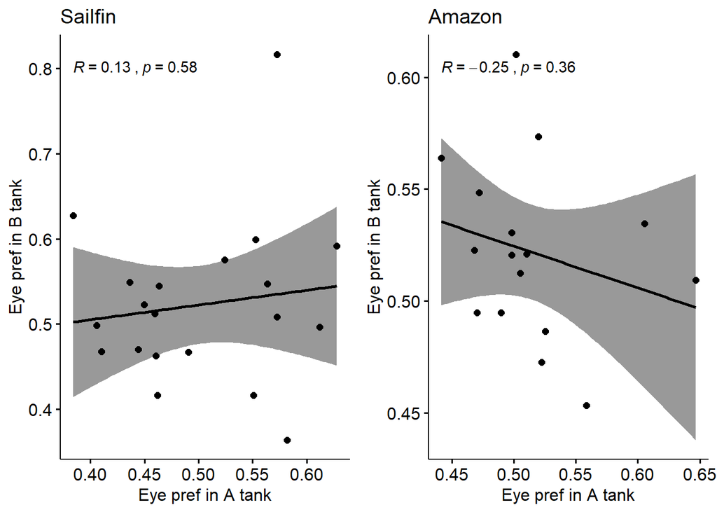

Correlation implication: With both correlations as insignificant, this means that there was no consistent eye use across trials. * Some form individuals who expressed left eye bias in A did express left eye bias in B, but the degree of bias was not that strong. *Is there a way to transform data in which I look at whether or not they were left-eye period vs right-eye (like it doesn’t matter their actual value, just if it’s above 0.5 it’s left)? Will this tell me anything differently?*

- With the LI instead of proportion data

```r
library(ggpubr)

cor.test(LAT_rawEX$LI.A, LAT_rawEX$LI.B, method ="pearson")
```

```
##
##  Pearson's product-moment correlation
##
## data:  LAT_rawEX$LI.A and LAT_rawEX$LI.B
## t = 0.23932, df = 23, p-value = 0.813
## alternative hypothesis: true correlation is not equal to 0
## 95 percent confidence interval:
##  -0.3522270  0.4363776
## sample estimates:
##        cor
## 0.04984049
```

```r
cor.test(FORM_rawextra$LI.A, FORM_rawextra$LI.B, method = "pearson")
```

```
##
##  Pearson's product-moment correlation
##
## data:  FORM_rawextra$LI.A and FORM_rawextra$LI.B
## t = -1.4361, df = 21, p-value = 0.1657
## alternative hypothesis: true correlation is not equal to 0
## 95 percent confidence interval:
##  -0.6331954  0.1290664
## sample estimates:
##        cor
## -0.2990455
```

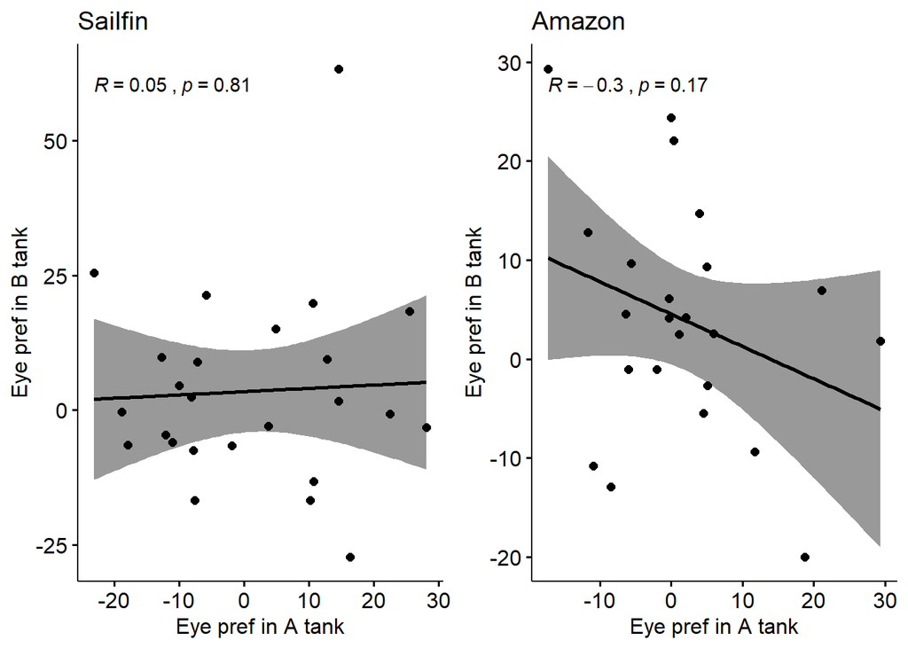

Will try out a Fischer’s exact test to test out repeatability of general preference –pearson’s correlation looking for the same degree of bias, but I just want to know if they were left in both cases, regardless of how strong that bias was.

Will creat contingency tables with left and right eye use by tank A and B for each species individually. Think I need to create a separate column that denotes whether the bias was left or right, so I’m going to try out an if-else loop.

```r
eyeB <- function(x) {
  if (x>0) {
    print("left")
  } else if (x<0) {
    print("right")
  } else
    print("none")

}



eyeL <- lapply(LAT_tankEX$LI.TOT, eyeB)
```

```
## [1] "left"
## [1] "right"
## [1] "right"
## [1] "right"
## [1] "left"
## [1] "right"
## [1] "left"
## [1] "right"
## [1] "right"
## [1] "left"
## [1] "right"
## [1] "left"
## [1] "right"
## [1] "right"
## [1] "left"
```

[output cut: 35 more lines]

```r
eyeL <- unlist(eyeL)
LAT_tankEX <- cbind(LAT_tankEX, eyeL)
LAT_tankEX
```

```
##    X.U.FEFF.SPP       NAME TANK LEFT RIGHT NA.      PROP      LI.TOT  eyeL
## 1         P.lat    Beijing    A  172   109  15 0.6120996  22.4199288  left
## 2         P.lat    Beijing    B  147   149   0 0.4966220  -0.6756757 right
## 3         P.lat     Camila    A  129   151  16 0.4607143  -7.8571429 right
## 4         P.lat     Camila    B  136   158   2 0.4625850  -7.4829932 right
## 5         P.lat    Jessica    A  171   123   2 0.5816327  16.3265306  left
## 6         P.lat    Jessica    B  104   182  10 0.3636360 -27.2727273 right
## 7         P.lat     London    A  157   128  11 0.5508772  10.1754386  left
## 8         P.lat     London    B  119   167  10 0.4160800 -16.7832168 right
## 9         P.lat    Melissa    A  127   164   5 0.4364261 -12.7147766 right
## 10        P.lat    Melissa    B  157   129  10 0.5489510   9.7902098  left
## 11        P.lat      Paris    A  130   153  13 0.4593640  -8.1272085 right
## 12        P.lat      Paris    B  150   143   3 0.5119450   2.3890785  left
## 13        P.lat      Penny    A  116   170  10 0.4055944 -18.8811189 right
## 14        P.lat      Penny    B  145   146   5 0.4982818  -0.3436426 right
```

[output cut: 36 more lines]

```r
eyeF <- lapply(FORM_tankextra$LI.TOT, eyeB)
```

```
## [1] "left"
## [1] "right"
## [1] "right"
## [1] "right"
## [1] "left"
## [1] "right"
## [1] "right"
## [1] "left"
## [1] "left"
## [1] "left"
## [1] "left"
## [1] "left"
## [1] "left"
## [1] "right"
## [1] "left"
```

[output cut: 31 more lines]

```r
eyeF <- unlist(eyeF)
FORM_tankextra <- cbind(FORM_tankextra, eyeF)
FORM_tankextra
```

```
##     X.U.FEFF.SPP    NAME TANK LEFT RIGHT NA.      PROP      LI.TOT  eyeF
## 51        P.form     Kai    A  135   122  39 0.5252918   5.0583658  left
## 52        P.form     Kai    B  126   133  37 0.4864865  -2.7027027 right
## 53        P.form   Maeve    A  129   153  14 0.4574468  -8.5106383 right
## 54        P.form   Maeve    B  108   140  48 0.4354839 -12.9032258 right
## 57        P.form   Freya    A  157   124  15 0.5587189  11.7437722  left
## 58        P.form   Freya    B  131   158   7 0.4532872  -9.3425606 right
## 59        P.form     Ana    A  132   150  14 0.4680851  -6.3829787 right
## 60        P.form     Ana    B  150   137   9 0.5226481   4.5296167  left
## 61        P.form  Ashley    A  172   112  12 0.6056338  21.1267606  left
## 62        P.form  Ashley    B  147   128  21 0.5345455   6.9090909  left
## 63        P.form     Ava    A  144   133  19 0.5198556   3.9711191  left
## 64        P.form     Ava    B  160   119  17 0.5734767  14.6953405  left
## 65        P.form   Chloe    A  152   139   5 0.5223368   4.4673540  left
## 66        P.form   Chloe    B  138   154   4 0.4726027  -5.4794521 right
```

[output cut: 32 more lines]

Now for fischer’s test

```r
fisher.test(LAT_tankEX$TANK, LAT_tankEX$eyeL, alternative = "two.sided", conf.int = TRUE)
```

```
##
##  Fisher's Exact Test for Count Data
##
## data:  LAT_tankEX$TANK and LAT_tankEX$eyeL
## p-value = 1
## alternative hypothesis: true odds ratio is not equal to 1
## 95 percent confidence interval:
##  0.2866588 3.4884677
## sample estimates:
## odds ratio
##          1
```

```r
fisher.test(FORM_tankextra$TANK, FORM_tankextra$eyeF, alternative = "two.sided", conf.int = TRUE)
```

```
##
##  Fisher's Exact Test for Count Data
##
## data:  FORM_tankextra$TANK and FORM_tankextra$eyeF
## p-value = 0.5499
## alternative hypothesis: two.sided
```